# Project.2: House Prices – Advanced Regression Techniques

시각화리포팅5조(penta-core)

2022-02-24

# 1 과제 목차

- EDA와 시각화를 통해 데이터를 이해하시오.
- 다양한 선형 회귀분석 방법을 적용하시오.
- 선형 회귀모델을 피팅하시오. (step, 규제화 등)
- R markdown으로 결과 보고서를 작성하시오

# 2 분석 준비 단계

## 2.1 패키지 로딩

```r
library(knitr)
library(ggplot2)
library(plyr)
library(dplyr)
library(corrplot)
library(caret)
library(gridExtra)
library(scales)
library(Rmisc)
library(ggrepel)
library(randomForest)
library(psych)
library(xgboost)
library(glmnet)
library(Amelia)
```

## 2.2 파일불러오기

```r
train <- read.csv('train.csv', stringsAsFactors = F)
test <- read.csv('test.csv', stringsAsFactors = F)
```

## 2.3 데이터 설명

Train Data는 character 변수와 integer 변수로 구성되어 있다. 대개의 Character 변수는 실제적으론 factor 변수이지만, 그들 중 대다수는 cleaning / feature engineering 이 필요하므로 character 변수로 R에 불러온다.

```r
str(train[,c(1:10, 81)]) # 종속 변수와 처음부터 10번째까지의 변수 확인
```

```
## 'data.frame':    1460 obs. of  11 variables:
##  $ Id         : int  1 2 3 4 5 6 7 8 9 10 ...
##  $ MSSubClass : int  60 20 60 70 60 50 20 60 50 190 ...
##  $ MSZoning   : chr  "RL" "RL" "RL" "RL" ...
##  $ LotFrontage: int  65 80 68 60 84 85 75 NA 51 50 ...
##  $ LotArea    : int  8450 9600 11250 9550 14260 14115 10084 10382 6120 7420 ...
##  $ Street     : chr  "Pave" "Pave" "Pave" "Pave" ...
##  $ Alley      : chr  NA NA NA NA ...
##  $ LotShape   : chr  "Reg" "Reg" "IR1" "IR1" ...
##  $ LandContour: chr  "Lvl" "Lvl" "Lvl" "Lvl" ...
##  $ Utilities  : chr  "AllPub" "AllPub" "AllPub" "AllPub" ...
##  $ SalePrice  : int  208500 181500 223500 140000 250000 143000 307000 200000 129900 118000 ...
```

```r
dim(train)               # data 구조 확인
```

```
## [1] 1460   81
```

구조 확인 결과 81개의 변수에 1460개의 관측치가 있으며, 종속 변수는 ‘SalePrice’ 변수이다.

```r
test_labels <- test$Id  # 후에 submission을 위해 test의 id는 벡터에 두고, 변수는 삭제한다.
test$Id <- NULL
train$Id <- NULL
```

```r
test$SalePrice <- NA   # rbind 사전 작업으로 변수 개수 맞추기 위해 SalePrice 변수 생성
all <- rbind(train, test)
dim(all)
```

```
## [1] 2919   80
```

# 3 가장 중요한 변수 탐색

Id 변수를 제외하고 79개의 독립 변수와, 1개의 종속 변수가 있다.

## 3.1 반응변수 : SalePrice

차트를 보면 오른쪽으로 치우친 분포다. 이건 소수의 사람이 고가의 집에 영향을 끼치는 것으로 보이며, 모델링 전에 이 분포는 손을 볼 예정이다.

참조) rbind 과정중 all에는 test의 SalePrice를 전부 NA로 넣었다. 그래서 is.na로 결측치 제외한 데이터를 로드하고 x축의 scale을 적용해서 차트를 만들었다.

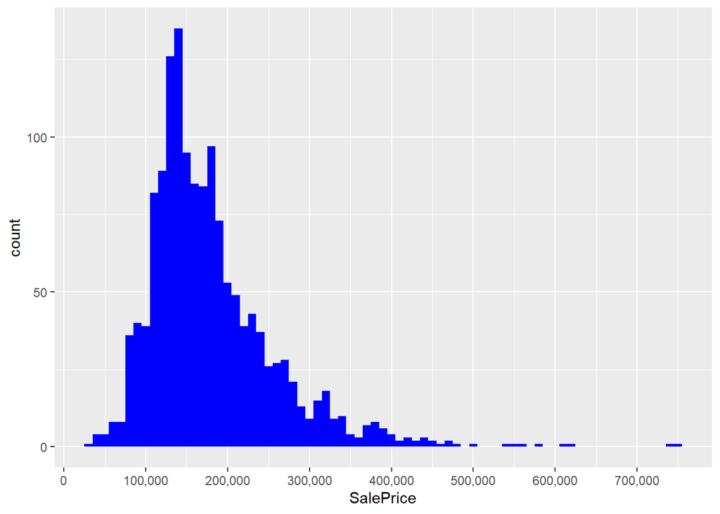

```r
ggplot(data = all[!is.na(all$SalePrice),], aes(x = SalePrice)) +
  geom_histogram(fill = 'blue', binwidth = 10000) +
  scale_x_continuous(breaks = seq(0, 800000, by = 100000), labels = comma) #0~80만까지 10만 단위로 x축 표현(구분자 ,)
```

```r
summary(all$SalePrice) # 요약값 확인
```

```
##    Min. 1st Qu.  Median    Mean 3rd Qu.    Max.    NA's
##   34900  129975  163000  180921  214000  755000    1459
```

```r
# 참조) 75%까지의 분포가 21만대 안에서 이뤄지며, 평균은 18만, 중위값은 16만이다.
# 참조) 최대값과는 차이가 나는데 추후 보정을 하겠다.
```

## 3.2 numeric 변수

character 변수는 사용하기 전에 전처리를 해야 한다. 대략적인 느낌을 위해, SalePrice와 상관 계수가 높은 numeric 변수들을 선별하겠다.

### 3.2.1 SalePrice와 상관관계

SalePrice와 양의 상관 관계를 가진 10개의 numeric 변수를 선정한다.(상관 계수 0.5 이상)

```r
numericVars <- which(sapply(all, is.numeric)) # index 벡터 numeric 변수 저장
numericVarNames <- names(numericVars) #이름 명명하여 변수 생성
cat('There are', length(numericVars), 'numeric variables')
```

```
## There are 37 numeric variables
```

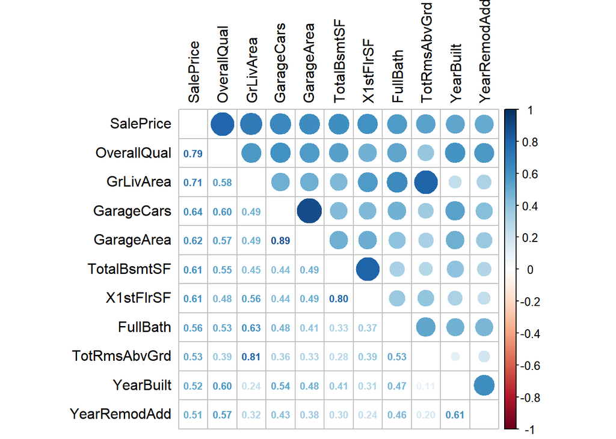

```r
all_numVar <- all[, numericVars]
cor_numVar <- cor(all_numVar, use='pairwise.complete.obs') # 전 numeric 변수의 상관 계수

# SalePrice와의 상관 계수 내림차순으로 정렬
cor_sorted <- as.matrix(sort(cor_numVar[, 'SalePrice'], decreasing = TRUE))
# 상관 계수가 큰 변수만을 선택
CorHigh <- names(which(apply(cor_sorted, 1, function(x) abs(x) > 0.5)))
cor_numVar <- cor_numVar[CorHigh, CorHigh]

corrplot.mixed(cor_numVar,
               tl.col = 'black',   # 변수명 색깔
               tl.pos = 'lt',      # 변수명 왼쪽 표시
               number.cex = .7)    # matrix안 상관계수 text 크기
```

행렬에서 보이는 많은 변수들중 상관 관계가 가장 높은 2개 독립 변수 ‘OverallQual’, ’GrLivArea’를 시각화 실시 (’GrLivArea’는 지하실 제외한 지상의 면적이다.)

다중공선성도 살펴보아야 함. 예를 들어, ‘GarageCars’ 와 ‘GarageArea’의 상관 계수는 매우 높은 0.89이며 이 수치는 ’SalePrice’와도 유사하게 높다. SalePrice와 0.5 이상의 상관 계수를 가진 변수들은 이렇다. ’TotalBsmtSF’ - ‘1stFlrSF’ - ‘FullBath’ - ‘TotRmsAbvGrd’ - ‘YearBuilt’ - ‘YearRemodAdd’.

### 3.2.2 Overall Quality

numeric 변수중 SalePrice와 상관 계수가 가장 큰(0.79) 변수이며, 집의 전반적인 재료와 마감의 평가로 수치는 1(아주 낮은) ~ 10(아주 높은)까지이다.

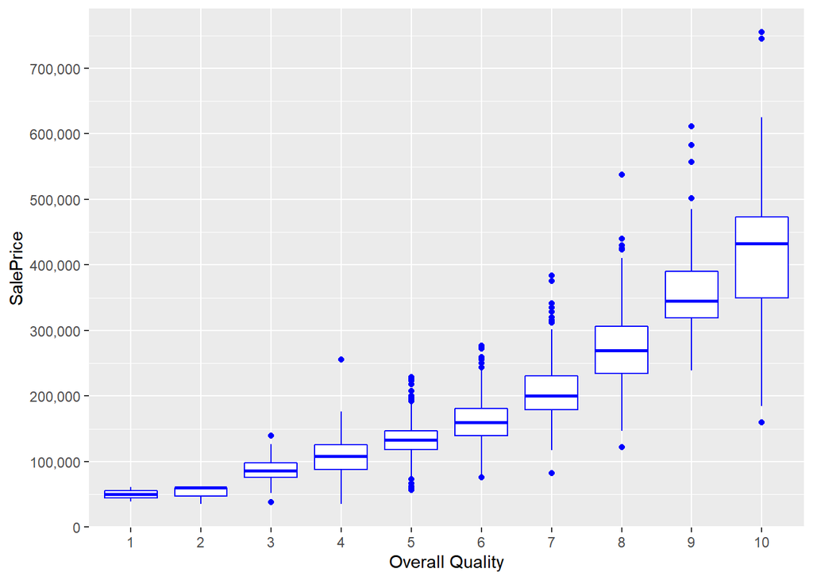

```r
ggplot(data = all[!is.na(all$SalePrice),], aes(x = factor(OverallQual), y = SalePrice)) +
  geom_boxplot(col = 'blue') + labs(x = 'Overall Quality') +
  scale_y_continuous(breaks = seq(0, 800000, by = 100000), labels = comma) #0~80만까지 10만단위로 y축 표현(구분자 ,)
```

SalePrice와 Overall Quality간은 양의 상관 관계를 보이며, 전반적으로 상향 곡선의 형태이다. 이상치는 특출난 값은 보이지 않는다. 후에 아웃라이어의 후보가 있다면, 4 등급의 비싼 집일 것이다.

### 3.2.3 Above Grade (Ground) Living Area (square feet)

numeric 변수중 SalePrice와 상관 계수가 두 번째로 큰 변수이며, 많은 관측치가 있지만 큰 집은 일반적으로 비싸다.

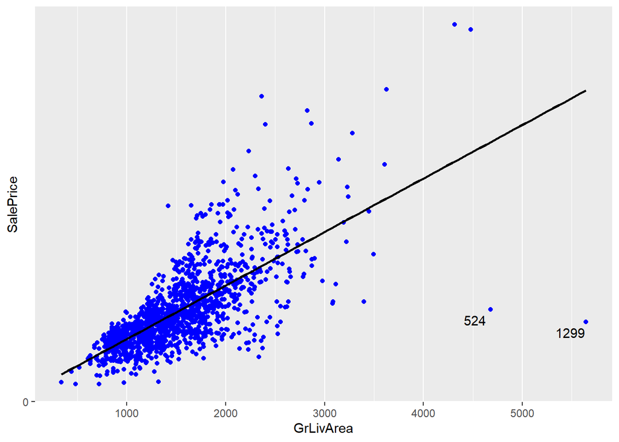

```r
ggplot(data = all[!is.na(all$SalePrice),], aes(x = GrLivArea, y = SalePrice)) +
  geom_point(col = 'blue') +
  geom_smooth(method = 'lm', se = FALSE, color = 'black', aes(group = 1)) +
  scale_y_continuous(breaks = seq(0, 800000, by = 1000000), labels = comma) +
  geom_text_repel(aes(label = ifelse(all$GrLivArea[!is.na(all$SalePrice)] > 4500, #price 4500이상 텍스트 표기
  rownames(all), '')))
```

면적 대비 가격이 낮은 두 개의 이상치 같은 것이 보인다.(524, 1299번). 위험할 수 있기에 이것을 아웃라이어로 배제하는건 아직 안하겠다. 예를 들어 Overall Quality의 낮은 등급은 낮은 가격을 설명하지만, 보이는 바와 같이 2채의 집은 실제적으로 최고 등급의 집이다. 따라서 1299, 524 두 채의 집은 일단 이상치 후보로 두기로 한다.

```r
all[c(524, 1299), c('SalePrice', 'GrLivArea', 'OverallQual')]
```

```
##      SalePrice GrLivArea OverallQual
## 524     184750      4676          10
## 1299    160000      5642          10
```

# 4 Missing data, label encoding, and factorizing variables

## 4.1 Completeness of the data

우선 결측치를 포함한 변수들부터 확인해 보겠다.

```r
NAcol <- which(colSums(is.na(all)) > 0)  # 모든 결측치 변수 생성
sort(colSums(sapply(all[NAcol], is.na)), decreasing = TRUE) #결측치 변수 별로 내림차순 정렬
```

```
##       PoolQC  MiscFeature        Alley        Fence    SalePrice  FireplaceQu
##         2909         2814         2721         2348         1459         1420
##  LotFrontage  GarageYrBlt GarageFinish   GarageQual   GarageCond   GarageType
##          486          159          159          159          159          157
##     BsmtCond BsmtExposure     BsmtQual BsmtFinType2 BsmtFinType1   MasVnrType
##           82           82           81           80           79           24
##   MasVnrArea     MSZoning    Utilities BsmtFullBath BsmtHalfBath   Functional
##           23            4            2            2            2            2
##  Exterior1st  Exterior2nd   BsmtFinSF1   BsmtFinSF2    BsmtUnfSF  TotalBsmtSF
##            1            1            1            1            1            1
##   Electrical  KitchenQual   GarageCars   GarageArea     SaleType
##            1            1            1            1            1
```

```r
cat('There are', length(NAcol), 'columns with missing values')
```

```
## There are 35 columns with missing values
```

’SalePrice’의 1459개의 결측치는 test 셋의 수와 완벽하게 일치한다. 이건 34개의 독립 변수에서 NA를 수정해야 한다는 것을 의미한다.

## 4.2 결측데이터

- 결측치가 포함된 34개 독립 변수를 수정할려고 한다. (개수의 내림차순으로 작업)
- 다른 변수와 유의미한 관계를 갖는 변수를 찾는다면, 그룹핑!

### 4.2.1 Pool variables

PoolQC는 가장 많은 결측치가 있다. 세부 사항은 아래와 같다.

PoolQC: Pool quality

```
Ex  Excellent
Gd  Good
TA  Average/Typical
Fa  Fair
NA  No Pool
```

결측치에 ‘No pool’ 명시를 해야 하고, 또한 NA의 높은 수는 이것이 일반적이고, 수영장이 있는 집들은 소수라는 걸 보여준다.

```r
all$PoolQC[is.na(all$PoolQC)] <- 'None'
```

이 변수들을 순서형으로 변환하고, 동일한 품질 수준을 쓰는 다양한 변수가 있으므로 이후에 사용하기 위해 벡터를 만들겠다.

```r
Qualities <- c('None' = 0, 'Po' = 1, 'Fa' = 2, 'TA' = 3, 'Gd' = 4, 'Ex' = 5)
```

revalue 함수를 사용해서 정수형으로 변환을 하겠다.

```r
all$PoolQC <- as.integer(revalue(all$PoolQC, Qualities))
table(all$PoolQC)
```

```
##
##    0    2    4    5
## 2909    2    4    4
```

결측치는 없지만, Pool과 연관된 변수가 하나 더 있다. ‘PoolArea’ 변수이다. 여기엔 PoolQc가 없는 3채가 있다. 두 변수간의 명확한 관계가 있는지 확인을 위해 살펴봤지만 없었고, PoolQC가 없는 3변수는 Overall Quality에 맞춰 변수를 부여했다.

```r
all[all$PoolArea > 0 & all$PoolQC == 0, c('PoolArea', 'PoolQC', 'OverallQual')]
```

```
##      PoolArea PoolQC OverallQual
## 2421      368      0           4
## 2504      444      0           6
## 2600      561      0           3
```

```r
all$PoolQC[2421] <- 2
all$PoolQC[2504] <- 3
all$PoolQC[2600] <- 2
```

### 4.2.2 Miscellaneous Feature

Miscellanuous Feature 변수는 2814개의 결측치가 있고, 데이터 타입은 순서형이 아니기에 factor로 변환했다.

```
Elev  Elevator
Gar2  2nd Garage (if not described in garage section)
Othr  Other
Shed  Shed (over 100 SF)  #헛간
TenC  Tennis Court
NA    None
```

```
## No summary function supplied, defaulting to `mean_se()`
```

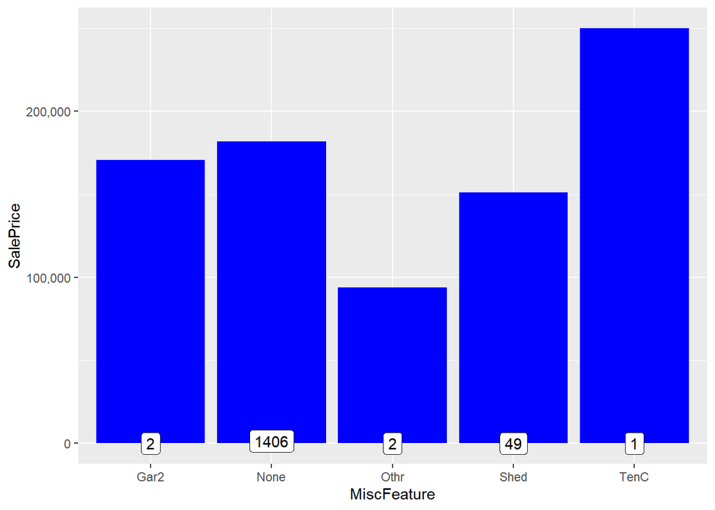

```r
all$MiscFeature[is.na(all$MiscFeature)] <- 'None'  #MiscFeature 결측치 'None' 치환
all$MiscFeature <- as.factor(all$MiscFeature)

ggplot(all[!is.na(all$SalePrice),], aes(x = MiscFeature, y = SalePrice)) +
  geom_bar(stat = 'summary', fun.y = 'median', fill = 'blue') +
  scale_y_continuous(breaks = seq(0, 800000, by = 100000), labels = comma) +
  geom_label(stat = 'count', aes(label = ..count.., y = ..count..)) #막대 그래프 count 라벨링
```

```r
table(all$MiscFeature)
```

```
##
## Gar2 None Othr Shed TenC
##    5 2814    4   95    1
```

빈도를 볼 때, 그 변수는 무의미해 보인다. 헛간이 있는 낮은 가격은 ’no Garage’일 것이라 추측한다. 테니스 코트가 있는 집은 비싸고, 단 한 곳 뿐이었다.

### 4.2.3 Alley

2721개의 결측치가 보이며, 데이터 타입은 순서형이 아니기에 factor로 변환했다.

```
Grvl  Gravel
Pave  Paved
NA    No alley access
```

```
## No summary function supplied, defaulting to `mean_se()`
```

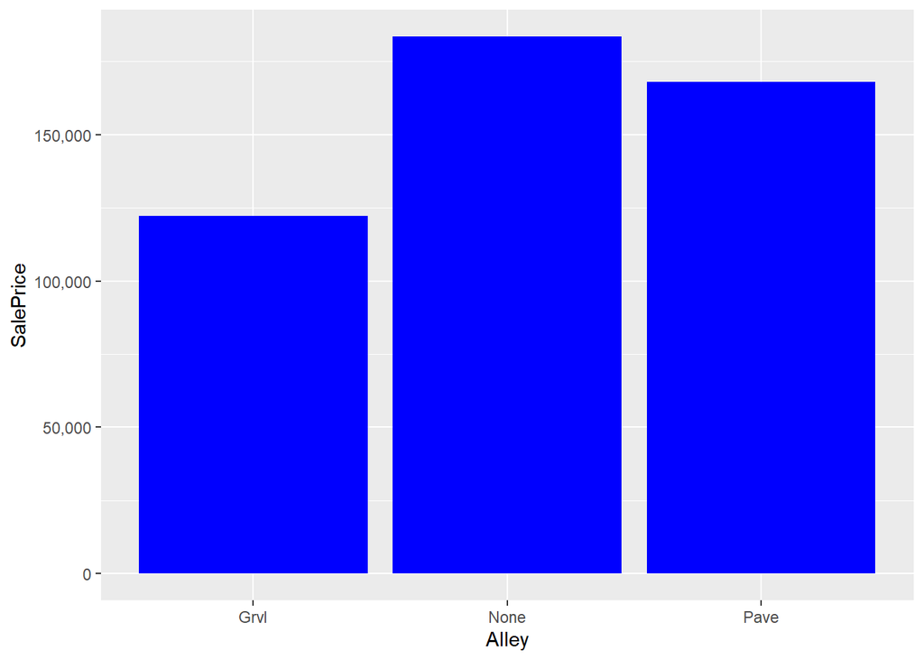

```r
all$Alley[is.na(all$Alley)] <- 'None'
all$Alley <- as.factor(all$Alley)
ggplot(all[!is.na(all$SalePrice),], aes(x = Alley, y = SalePrice)) +
  geom_bar(stat = 'summary', fun.y = 'median', fill = 'blue') +
  scale_y_continuous(breaks = seq(0, 200000, by = 50000), labels = comma)
```

```r
table(all$Alley)
```

```
##
## Grvl None Pave
##  120 2721   78
```

### 4.2.4 Fence

** Fence quality **

2348개의 결측치가 보이고, 순서형 변수로 보이기에 그대로 작업한다.

```
GdPrv   Good Privacy
MnPrv   Minimum Privacy
GdWo    Good Wood
MnWw    Minimum Wood/Wire
NA      No Fence
```

```r
all$Fence[is.na(all$Fence)] <- 'None'
table(all$Fence)
```

```
##
## GdPrv  GdWo MnPrv  MnWw  None
##   118   112   329    12  2348
```

```r
all[!is.na(all$SalePrice),] %>%
  group_by(Fence) %>%  #Fence 그룹핑
  summarise(median = median(SalePrice), counts = n()) #Fence변수의 price 중위값, 개수 확인
```

```
## # A tibble: 5 x 3
##   Fence median counts
##   <chr>  <dbl>  <int>
## 1 GdPrv 167500     59
## 2 GdWo  138750     54
## 3 MnPrv 137450    157
## 4 MnWw  130000     11
## 5 None  173000   1179
```

확인 결과 Fence가 순서형 변수가 아니어서(no fence is best), factor 타입으로 변환한다.

```r
all$Fence <- as.factor(all$Fence)
```

### 4.2.5 Fireplace variables

** Fireplace quality, and Number of fireplaces **

Fireplace Qulity에는 1420개의 결측치가 보이지만, Fireplaces는 완벽하다.

** Fireplace quality **

FireplaceQu 결측치의 수는 fireplaces 변수가 0인 수와 일치한다. 이건 이 결측치를 ’no fireplace’로 바꾸는데 무리가 없다는 걸 말한다. 이건 순서형 범주이고, Pool Quality를 위해 이전에 만들어둔 Qulaites 벡터를 쓰겠다.

```
 Ex   Excellent - Exceptional Masonry Fireplace
 Gd   Good - Masonry Fireplace in main level
 TA   Average - Prefabricated Fireplace in main living area or Masonry Fireplace in basement
 Fa     Fair - Prefabricated Fireplace in basement
 Po     Poor - Ben Franklin Stove
 NA     No Fireplace
```

```r
all$FireplaceQu[is.na(all$FireplaceQu)] <- 'None'
all$FireplaceQu <- as.integer(revalue(all$FireplaceQu, Qualities))
table(all$FireplaceQu)
```

```
##
##    0    1    2    3    4    5
## 1420   46   74  592  744   43
```

** Number of fireplaces **

Fireplaces는 정수형 변수이고, 결측치는 없기에 별도의 작업이 필요없다.

```r
table(all$Fireplaces)      #Fireplaces의 범주별 개수 확인
```

```
##
##    0    1    2    3    4
## 1420 1268  219   11    1
```

```r
sum(table(all$Fireplaces)) #합산한 개수가 변수의 총 개수와 같은지 확인
```

```
## [1] 2919
```

### 4.2.6 Lot variables

3개의 변수가 있으며 이 중 하나는 결측치가 있고, 2개는 결측치가 없다.

** LotFrontage: Linear feet of street connected to property **

결측치는 486개이고, 각각 동네들의 중위값을 구해 이를 대체하겠다.

```
## No summary function supplied, defaulting to `mean_se()`
```

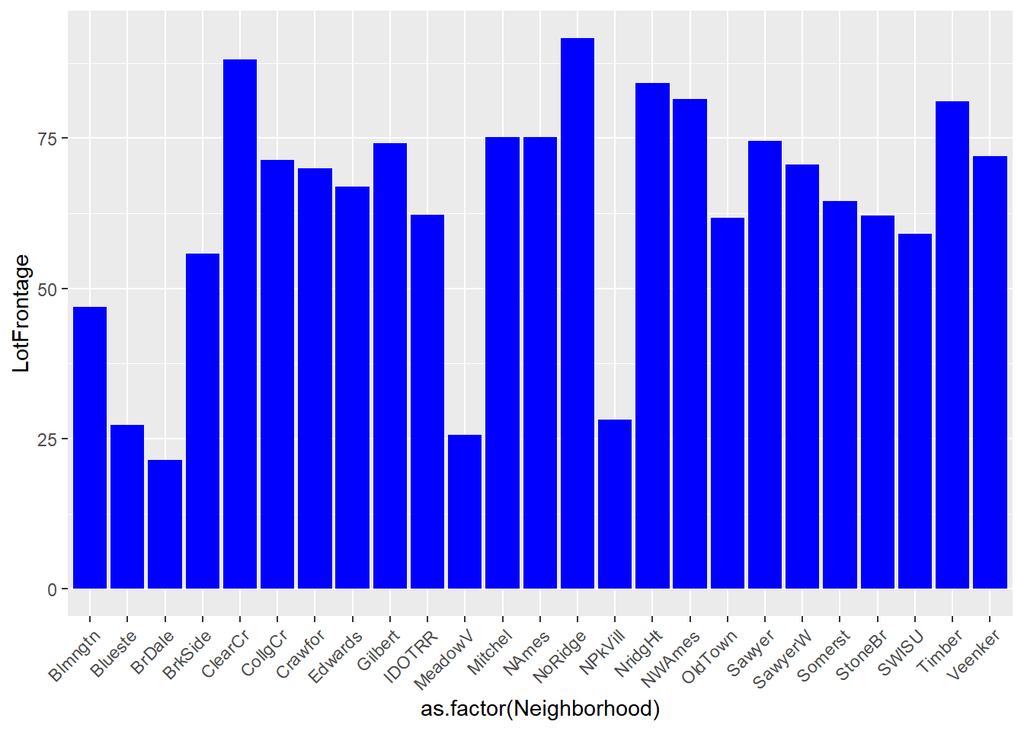

```r
ggplot(all[!is.na(all$LotFrontage),],
       aes(x = as.factor(Neighborhood), y = LotFrontage)) +
       geom_bar(stat = 'summary', fun.y = 'median', fill = 'blue') +
       theme(axis.text.x = element_text(angle = 45, hjust = 1)) # Text 45도 기울기, 높이는 1로 설정
```

상기 확인된 결측치를 반복문을 돌려 모두 대체!

```r
for (i in 1:nrow(all)) {
        if(is.na(all$LotFrontage[i])){
          all$LotFrontage[i] <- as.integer(median(all$LotFrontage[all$Neighborhood==all$Neighborhood[i]],
                                                  na.rm = TRUE))
        }
}
```

** LotShape: General shape of property **

결측치가 없고, 값은 순서형 타입으로 보인다.

```
 Reg    Regular
 IR1    Slightly irregular
 IR2    Moderately Irregular
 IR3    Irregular
```

```r
all$LotShape <- as.integer(revalue(all$LotShape, c('IR3' = 0, 'IR2' = 1, 'IR1' = 2, 'Reg' = 3)))
table(all$LotShape)
```

```
##
##    0    1    2    3
##   16   76  968 1859
```

```r
sum(table(all$LotShape))
```

```
## [1] 2919
```

** LotConfig: Lot configuration **

결측치가 없다. 순서형 타입으로 보였지만, 확인해보니 아니었다. 그래서 factor 타입으로 변환하겠다.

```
 Inside   Inside lot
 Corner   Corner lot
 CulDSac  Cul-de-sac
 FR2  Frontage on 2 sides of property
 FR3  Frontage on 3 sides of property
```

```
## No summary function supplied, defaulting to `mean_se()`
```

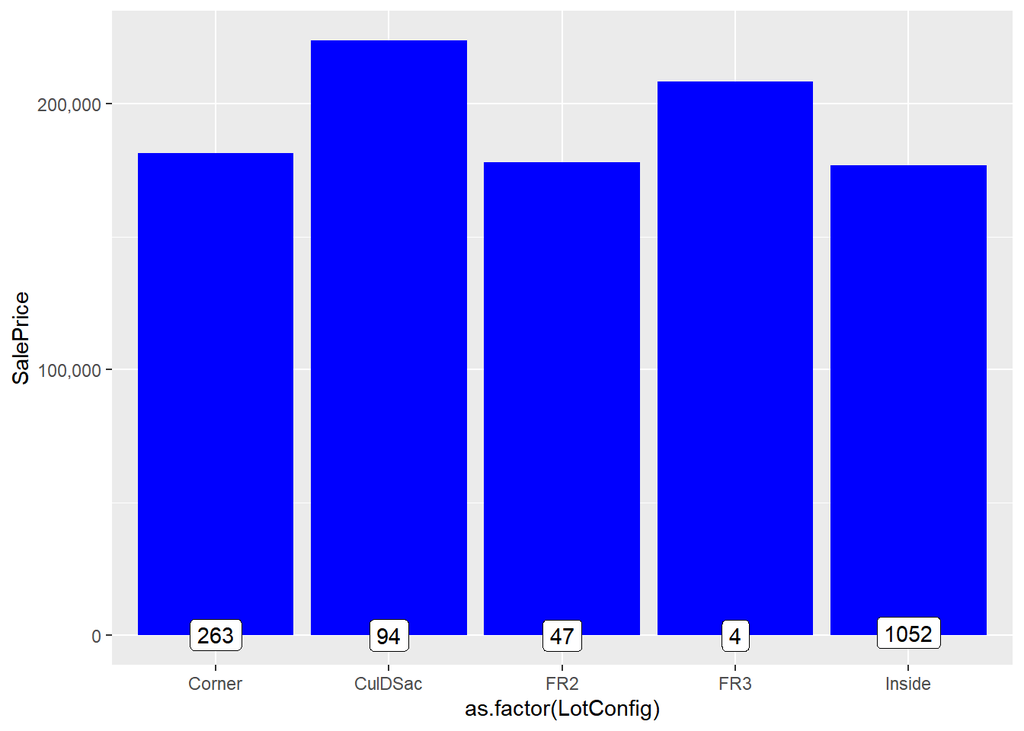

```r
ggplot(all[!is.na(all$SalePrice),], aes(x = as.factor(LotConfig), y = SalePrice)) +
  geom_bar(stat = 'summary', fun.y = 'median', fill = 'blue') +
  scale_y_continuous(breaks = seq(0, 800000, by = 100000), labels = comma) +
  geom_label(stat = 'count', aes(label = ..count.., y = ..count..))
```

```r
all$LotConfig <- as.factor(all$LotConfig)
table(all$LotConfig)
```

```
##
##  Corner CulDSac     FR2     FR3  Inside
##     511     176      85      14    2133
```

```r
sum(table(all$LotConfig))
```

```
## [1] 2919
```

### 4.2.7 Garage variables

** Garage 관련 7개 변수가 있다 **

결측치의 개수는 2개 변수(GarageCars, GarageArea)가 1개, 1개 변수(GarageType)가 157개, 나머지 4개 변수가 159개이다. 먼저 159개의 결측치가 있는 ** GarageYrBlt:창고 건축년도 ** 의 결측치 값을 YearBuilt의 값으로 대체하겠다. (리모델링이나 증축을 하지 않은 YearBuilt의 default값이 YearReomdAdd 변수와 유사하다.)

```r
all$GarageYrBlt[is.na(all$GarageYrBlt)] <- all$YearBuilt[is.na(all$GarageYrBlt)]
```

결측치는 문자형 타입이며 ’no garage’를 의미하기에, 157개와 159개의 결측치를 가진 세 변수의 차이점을 찾아보겠다.

```r
#157개의 결측치가 159개 결측치의 변수와 동일한 관측치인지 확인해 보겠다.
length(which(is.na(all$GarageType) & is.na(all$GarageFinish) & is.na(all$GarageCond) & is.na(all$GarageQual)))
```

```
## [1] 157
```

```r
#나머지 2개의 관측치를 찾아보겠다.
kable(all[!is.na(all$GarageType) & is.na(all$GarageFinish),
          c('GarageCars', 'GarageArea', 'GarageType', 'GarageCond', 'GarageQual', 'GarageFinish')])
```

|  | GarageCars | GarageArea | GarageType | GarageCond | GarageQual | GarageFinish |
| --- | --- | --- | --- | --- | --- | --- |
| 2127 | 1 | 360 | Detchd | NA | NA | NA |
| 2577 | NA | NA | Detchd | NA | NA | NA |

‘GarageType’의 157개 결측치는 ’GarageCondition’, ‘GarageQuality’, ’GarageFinish’에 있는 결측치를 나타낸다. 2127과 2577 두채의 다른 집을 찾았다. 2127은 창고가 있지만, 2577은 없는 것처럼 보인다. 즉 총 158개의 집이 창고가 없으며, 2127의 결측치는 159개 세 변수의 가장 많은 값으로 대체하겠다.

```r
# 최빈도 값으로 결측치 대체
all$GarageCond[2127] <- names(sort(-table(all$GarageCond)))[1]
all$GarageQual[2127] <- names(sort(-table(all$GarageQual)))[1]
all$GarageFinish[2127] <- names(sort(-table(all$GarageFinish)))[1]

# 대체 후 값 확인
kable(all[2127, c('GarageYrBlt', 'GarageCars', 'GarageArea', 'GarageType', 'GarageCond', 'GarageQual', 'GarageFinish')])
```

|  | GarageYrBlt | GarageCars | GarageArea | GarageType | GarageCond | GarageQual | GarageFinish |
| --- | --- | --- | --- | --- | --- | --- | --- |
| 2127 | 1910 | 1 | 360 | Detchd | TA | TA | Unf |

** GarageCars and GarageArea: 창고내 차 대수, 창고 면적 **

상기 두 변수 다 1개의 결측치가 있으며, 그건 2577 house이다. 이건 지금껏의 관측에서 찾아봤듯이 모든 Garage 변수에서 2577은 ’no Garage’를 나타낸다.

```r
# 2577 house에 값을 할당
all$GarageCars[2577] <- 0
all$GarageArea[2577] <- 0
all$GarageType[2577] <- NA

# 문자형 변수인 4 변수의 결측치가 모두 158개인지 확인해보겠다.
length(which(is.na(all$GarageType) & is.na(all$GarageFinish) & is.na(all$GarageCond) & is.na(all$GarageQual)))
```

```
## [1] 158
```

4개의 문자형 변수는 Garage와 연관이 있으며 모든 셋에 158개의 동일한 결측치가 있고, 이건 “No Garage”를 의미한다. 이 섹션에서 이걸 수정했다.

** GarageType: Garage 위치에 따른 다입 **

순서형 변수가 아니기에 factor 타입으로 변환하겠다.

```
 2Types   More than one type of garage
 Attchd   Attached to home
 Basment  Basement Garage
 BuiltIn  Built-In (Garage part of house - typically has room above garage)
 CarPort  Car Port
 Detchd   Detached from home
 NA       No Garage
```

```r
all$GarageType[is.na(all$GarageType)] <- 'No Garage'
all$GarageType <- as.factor(all$GarageType)
table(all$GarageType)
```

```
##
##    2Types    Attchd   Basment   BuiltIn   CarPort    Detchd No Garage
##        23      1723        36       186        15       778       158
```

** GarageFinish: Garage 인테리어 완료 **

순서형 변수이다.

```
 Fin  Finished
 RFn  Rough Finished
 Unf  Unfinished
 NA   No Garage
```

```r
all$GarageFinish[is.na(all$GarageFinish)] <- 'None'
Finish <- c('None' = 0, 'Unf' = 1, 'RFn' = 2, 'Fin' = 3) #문자형 수치형으로 변환

all$GarageFinish <- as.integer(revalue(all$GarageFinish, Finish))
table(all$GarageFinish)
```

```
##
##    0    1    2    3
##  158 1231  811  719
```

** GarageQual: Garage Quality **

Qualities 벡터로 순서형으로 변환한다.

```
 Ex   Excellent
 Gd   Good
 TA   Typical/Average
 Fa   Fair
 Po   Poor
 NA   No Garage
```

```r
all$GarageQual[is.na(all$GarageQual)] <- 'None'
all$GarageQual <- as.integer(revalue(all$GarageQual, Qualities))
table(all$GarageQual)
```

```
##
##    0    1    2    3    4    5
##  158    5  124 2605   24    3
```

** GarageCond: Garage condition **

Qualities 벡터로 순서형으로 변환한다.

```
 Ex   Excellent
 Gd   Good
 TA   Typical/Average
 Fa   Fair
 Po   Poor
 NA   No Garage
```

```r
all$GarageCond[is.na(all$GarageCond)] <- 'None'
all$GarageCond <- as.integer(revalue(all$GarageCond, Qualities))
table(all$GarageCond)
```

```
##
##    0    1    2    3    4    5
##  158   14   74 2655   15    3
```

### 4.2.8 Basement variables

** Basement 관련 변수는 11개이다 **

이 중 5개 변수는 79 - 82개의 결측치고, 6개 변수는 1개 또는 2개의 결측치가 있다.

```r
# 79개의 결측치가 80 이상의 결측치의 값과 동일한 관측치를 보이는지 확인하겠다.
length(which(is.na(all$BsmtQual) & is.na(all$BsmtCond) & is.na(all$BsmtExposure) &
               is.na(all$BsmtFinType1) & is.na(all$BsmtFinType2)))
```

```
## [1] 79
```

```r
# 추가 결측치 찾기: BsmtFinType1은 결측치가 아니지만, 다른 4개 변수들이 결측치인 경우
all[!is.na(all$BsmtFinType1) & (is.na(all$BsmtCond) | is.na(all$BsmtQual) |
                                is.na(all$BsmtExposure) | is.na(all$BsmtFinType2)),
    c('BsmtQual', 'BsmtCond', 'BsmtExposure', 'BsmtFinType1', 'BsmtFinType2')]
```

```
##      BsmtQual BsmtCond BsmtExposure BsmtFinType1 BsmtFinType2
## 333        Gd       TA           No          GLQ         <NA>
## 949        Gd       TA         <NA>          Unf          Unf
## 1488       Gd       TA         <NA>          Unf          Unf
## 2041       Gd     <NA>           Mn          GLQ          Rec
## 2186       TA     <NA>           No          BLQ          Unf
## 2218     <NA>       Fa           No          Unf          Unf
## 2219     <NA>       TA           No          Unf          Unf
## 2349       Gd       TA         <NA>          Unf          Unf
## 2525       TA     <NA>           Av          ALQ          Unf
```

확인 결과, 79채가 지하실이 없는 것처럼 보인다. 그 중 9채는 중간 중간 결측치가 보이는데, 이건 각 변수를 내림차순으로 정렬해 가장 빈도수가 높은 값으로 대체하겠다.

```r
# 최빈도값으로 대체값 할당
all$BsmtFinType2[333] <- names(sort(-table(all$BsmtFinType2)))[1]
all$BsmtExposure[c(949, 1488, 2349)] <- names(sort(-table(all$BsmtExposure)))[1]
all$BsmtQual[c(2218,2219)] <- names(sort(-table(all$BsmtQual)))[1]
all$BsmtCond[c(2041, 2186, 2525)] <- names(sort(-table(all$BsmtCond)))[1]
```

79~82개의 결측치를 가진 5개 변수는 지하실이 없어 보여, factorize/ hot encode하겠다.

** BsmtQual: 지하실 높이를 등급화 **

Qualities 벡터로 순서형으로 변환한다.

```
 Ex   Excellent (100+ inches)
 Gd   Good (90-99 inches)
 TA   Typical (80-89 inches)
 Fa   Fair (70-79 inches)
 Po   Poor (<70 inches
 NA   No Basement
```

```r
all$BsmtQual[is.na(all$BsmtQual)] <- 'None'
all$BsmtQual <- as.integer(revalue(all$BsmtQual, Qualities))
table(all$BsmtQual)
```

```
##
##    0    2    3    4    5
##   79   88 1285 1209  258
```

** BsmtCond: 지하실의 일반적인 상태로 본 등급 **

Qualities 벡터로 순서형으로 변환한다.

```
 Ex   Excellent
 Gd   Good
 TA   Typical - slight dampness allowed
 Fa   Fair - dampness or some cracking or settling
 Po   Poor - Severe cracking, settling, or wetness
 NA   No Basement
```

```r
all$BsmtCond[is.na(all$BsmtCond)] <- 'None'
all$BsmtCond <- as.integer(revalue(all$BsmtCond, Qualities))
table(all$BsmtCond)
```

```
##
##    0    1    2    3    4
##   79    5  104 2609  122
```

** BsmtExposure: 벽이나 정원의 도보 적합도 수준 **

변수는 순서형 타입이다.

```
 Gd   Good Exposure
 Av   Average Exposure (split levels or foyers typically score average or above)
 Mn   Mimimum Exposure
 No   No Exposure
 NA   No Basement
```

```r
all$BsmtExposure[is.na(all$BsmtExposure)] <- 'None'
Exposure <- c('None' = 0, 'No' = 1, 'Mn' = 2, 'Av' = 3, 'Gd' = 4)

all$BsmtExposure <- as.integer(revalue(all$BsmtExposure, Exposure))
table(all$BsmtExposure)
```

```
##
##    0    1    2    3    4
##   79 1907  239  418  276
```

** BsmtFinType1: 지하실 완공 면적의 등급 **

변수는 순서형 타입이다.

```
 GLQ  Good Living Quarters
 ALQ  Average Living Quarters
 BLQ  Below Average Living Quarters
 Rec  Average Rec Room
 LwQ  Low Quality
 Unf  Unfinshed
 NA   No Basement
```

```r
all$BsmtFinType1[is.na(all$BsmtFinType1)] <- 'None'
Fintype <- c('None' = 0, 'Unf' = 1, 'LwQ' = 2, 'Rec' = 3, 'BLQ' = 4, 'ALQ' = 5, 'GLQ' = 6)

all$BsmtFinType1 <- as.integer(revalue(all$BsmtFinType1, Fintype))
table(all$BsmtFinType1)
```

```
##
##   0   1   2   3   4   5   6
##  79 851 154 288 269 429 849
```

** BsmtFinType2: multiple type일 경우의 지하실 완공 면적 등급 **

변수는 순서형 타입이고, Fintype 벡터이다.

```
 GLQ  Good Living Quarters
 ALQ  Average Living Quarters
 BLQ  Below Average Living Quarters
 Rec  Average Rec Room
 LwQ  Low Quality
 Unf  Unfinshed
 NA   No Basement
```

```r
all$BsmtFinType2[is.na(all$BsmtFinType2)] <- 'None'
all$BsmtFinType2 <- as.integer(revalue(all$BsmtFinType2, Fintype))
table(all$BsmtFinType2)
```

```
##
##    0    1    2    3    4    5    6
##   79 2494   87  105   68   52   34
```

** 결측치 1~2개의 남은 6개 변수 **

소수의 결측치를 가진 남은 6개 변수를 확인해보자

```r
# 상기에 관측했던 지하실이 없었던 79채를 참고하여 남은 결측치를 확인해보자
all[(is.na(all$BsmtFullBath) | is.na(all$BsmtHalfBath) | is.na(all$BsmtFinSF1) |
       is.na(all$BsmtFinSF2) | is.na(all$BsmtUnfSF) | is.na(all$TotalBsmtSF)),
    c('BsmtQual', 'BsmtFullBath', 'BsmtHalfBath', 'BsmtFinSF1', 'BsmtFinSF2', 'BsmtUnfSF', 'TotalBsmtSF')]
```

```
##      BsmtQual BsmtFullBath BsmtHalfBath BsmtFinSF1 BsmtFinSF2 BsmtUnfSF
## 2121        0           NA           NA         NA         NA        NA
## 2189        0           NA           NA          0          0         0
##      TotalBsmtSF
## 2121          NA
## 2189           0
```

확인 결과 2채의 집에 결측치를 발견했고, 결측치는 0으로 대체하겠다.

** BsmtFullBath: full bathrooms을 갖춘 지하실 **

정수형 타입의 변수이다.

```r
all$BsmtFullBath[is.na(all$BsmtFullBath)] <- 0
table(all$BsmtFullBath)
```

```
##
##    0    1    2    3
## 1707 1172   38    2
```

** BsmtHalfBath: half bathrooms을 갖춘 지하실 **

정수형 타입의 변수이다.

```r
all$BsmtHalfBath[is.na(all$BsmtHalfBath)] <- 0
table(all$BsmtHalfBath)
```

```
##
##    0    1    2
## 2744  171    4
```

** BsmtFinSF1: 크기가 1 평방 미터인 지하실 **

정수형 타입의 변수이다.

```r
all$BsmtFinSF1[is.na(all$BsmtFinSF1)] <- 0
```

** BsmtFinSF2: 크기가 2 평방 미터인 지하실 **

정수형 타입의 변수이다.

```r
all$BsmtFinSF2[is.na(all$BsmtFinSF2)] <- 0
```

** BsmtUnfSF: 면적이 평방 미터로 측정이 안되는 지하실**

정수형 타입의 변수이다.

```r
all$BsmtUnfSF[is.na(all$BsmtUnfSF)] <- 0
```

** TotalBsmtSF: 지하실의 총 평방 미터**

정수형 타입의 변수이다.

```r
all$TotalBsmtSF[is.na(all$TotalBsmtSF)] <- 0
```

### 4.2.9 Masonry variables

** Masonry veneer type, and masonry veneer area **

결측치가 Masonry veneer type은 24개, veneer area는 23개이다. veneer area를 가진 집이면, veneer type일텐데 결측치 개수가 맞지 않는게 이상하다. 수정을 해보자

```r
# veneer area의 23개 결측치가 veneer type의 23개 결측치인지 확인해 보겠다.
length(which(is.na(all$MasVnrType) & is.na(all$MasVnrArea)))
```

```
## [1] 23
```

```r
# veneer type의 1개 결측치를 찾아보자.
all[is.na(all$MasVnrType) & !is.na(all$MasVnrArea), c('MasVnrType', 'MasVnrArea')]
```

```
##      MasVnrType MasVnrArea
## 2611       <NA>        198
```

```r
#veneer type의 결측치를 최빈도값으로 대체하자
all$MasVnrType[2611] <- names(sort(-table(all$MasVnrType)))[2] #최빈도는 'none'이라 두번째 빈도로 했다.
all[2611, c('MasVnrType', 'MasVnrArea')]
```

```
##      MasVnrType MasVnrArea
## 2611    BrkFace        198
```

veneer type과 veneer area의 동일한 23개 결측치는 석조가 없는걸 의미한다(no masonry)

** Masonry veneer type **

범주는 아래와 같다.

```
 BrkCmn   Brick Common
 BrkFace  Brick Face
 CBlock   Cinder Block
 None     None
 Stone    Stone
```

```r
all$MasVnrType[is.na(all$MasVnrType)] <- 'None'
all[!is.na(all$SalePrice),] %>%    #결측치 아닌 SalePrice 한정
  group_by(MasVnrType) %>%         # MasVnrType 변수로 그룹핑
  summarise(median = median(SalePrice), counts=n()) %>%  # SalePrice 중위값, 개수 요약
  arrange(median)                  # 중위값 순으로 오름차순 정렬
```

```
## # A tibble: 4 x 3
##   MasVnrType median counts
##   <chr>       <dbl>  <int>
## 1 BrkCmn     139000     15
## 2 None       143125    872
## 3 BrkFace    181000    445
## 4 Stone      246839    128
```

’common brick/none’과 다른 타입간에 중요한 차이가 보인다. 심플한 돌이나 목조로 만든 주택이 저렴할 걸로 추정된다. 확인해 보겠다.

```r
Masonry <- c('None' = 0, 'BrkCmn' = 0, 'BrkFace' = 1, 'Stone' = 2)
all$MasVnrType <- as.integer(revalue(all$MasVnrType, Masonry))
table(all$MasVnrType)
```

```
##
##    0    1    2
## 1790  880  249
```

** MasVnrArea: 평방 미터 안의 Masonry veneer area **

정수형 변수이다.

```r
all$MasVnrArea[is.na(all$MasVnrArea)] <- 0
```

### 4.2.10 MS Zoning

** MSZoning: 용도별 지구 식별자 **

결측치는 4개이고, 값은 범주형이다.

```
 A    Agriculture
 C    Commercial
 FV   Floating Village Residential
 I    Industrial
 RH   Residential High Density
 RL   Residential Low Density
 RP   Residential Low Density Park
 RM   Residential Medium Density
```

```r
# 최빈도값으로 결측치 대체
all$MSZoning[is.na(all$MSZoning)] <- names(sort(-table(all$MSZoning)))[1]
all$MSZoning <- as.factor(all$MSZoning)
table(all$MSZoning)
```

```
##
## C (all)      FV      RH      RL      RM
##      25     139      26    2269     460
```

```r
sum(table(all$MSZoning))
```

```
## [1] 2919
```

### 4.2.11 Kitchen variables

** Kitchen quality and number of Kitchens above grade **

Kitchen quality 는 결측치가 1개, number of Kitchen 은 결측치가 없다.

** Kitchen quality **

1개의 결측치가 있고, qualities vector로 순서형으로 변환하겠다.

```
 Ex   Excellent
 Gd   Good
 TA   Typical/Average
 Fa   Fair
 Po   Poor
```

```r
# 최빈도값으로 결측치 대체
all$KitchenQual[is.na(all$KitchenQual)] <- 'TA'
all$KitchenQual <- as.integer(revalue(all$KitchenQual, Qualities))
table(all$KitchenQual)
```

```
##
##    2    3    4    5
##   70 1493 1151  205
```

```r
sum(table(all$KitchenQual))
```

```
## [1] 2919
```

** Number of Kitchens above grade **

순서형 변주이고, 결측치는 없다.

```r
table(all$KitchenAbvGr)
```

```
##
##    0    1    2    3
##    3 2785  129    2
```

```r
sum(table(all$KitchenAbvGr))
```

```
## [1] 2919
```

### 4.2.12 Utilities

** Utilities: 사용할 수 있는 Utilities의 종류 **

결측치는 2개이다.

```
 AllPub   All public Utilities (E,G,W,& S)
 NoSewr   Electricity, Gas, and Water (Septic Tank)
 NoSeWa   Electricity and Gas Only
 ELO  Electricity only
```

관측된 데이터중 한 집을 제외하곤 모두 AllPub 이다. 한 집은 train 데이터에만 있고, test에는 없다. 결측치를 ’AllPub’으로 대체하는 것은 test set 의 모든 집이 ’AllPub’임을 의미한다. prediction때 이 변수를 사용하지 않기 위해 이 변수는 지우겠다.

```r
table(all$Utilities)
```

```
##
## AllPub NoSeWa
##   2916      1
```

```r
kable(all[is.na(all$Utilities) | all$Utilities == "NoSeWa", 1:9])
```

|  | MSSubClass | MSZoning | LotFrontage | LotArea | Street | Alley | LotShape | LandContour | Utilities |
| --- | --- | --- | --- | --- | --- | --- | --- | --- | --- |
| 945 | 20 | RL | 82 | 14375 | Pave | None | 2 | Lvl | NoSeWa |
| 1916 | 30 | RL | 109 | 21780 | Grvl | None | 3 | Lvl | NA |
| 1946 | 20 | RL | 64 | 31220 | Pave | None | 2 | Bnk | NA |

```r
all$Utilities <- NULL
```

### 4.2.13 Home functionality

** Functional: 홈 기능 **

```
 Typ  Typical Functionality
 Min1 Minor Deductions 1
 Min2 Minor Deductions 2
 Mod  Moderate Deductions
 Maj1 Major Deductions 1
 Maj2 Major Deductions 2
 Sev  Severely Damaged
 Sal  Salvage only
```

```r
# 최빈도값으로 결측치 대체
all$Functional[is.na(all$Functional)] <- names(sort(-table(all$Functional)))[1]
all$Functional <- as.integer(revalue(all$Functional, +
                  c('Sal' = 0, 'Sev' = 1, 'Maj2' = 2, 'Maj1' = 3, 'Mod' = 4, 'Min2' = 5, 'Min1' = 6, 'Typ' = 7)))
table(all$Functional)
```

```
##
##    1    2    3    4    5    6    7
##    2    9   19   35   70   65 2719
```

```r
sum(table(all$Functional))
```

```
## [1] 2919
```

### 4.2.14 Exterior variables

** 건물 외장 변수로 4개가 있다. **

2개의 변수는 결측치가 1개이고, 2개의 변수는 결측치가 없다.

** Exterior1st: 건물 외장 형태**

결측치는 1개이며, 값은 범주형이다.

```
 AsbShng  Asbestos Shingles
 AsphShn  Asphalt Shingles
 BrkComm  Brick Common
 BrkFace  Brick Face
 CBlock   Cinder Block
 CemntBd  Cement Board
 HdBoard  Hard Board
 ImStucc  Imitation Stucco
 MetalSd  Metal Siding
 Other    Other
 Plywood  Plywood
 PreCast  PreCast
 Stone    Stone
 Stucco   Stucco
 VinylSd  Vinyl Siding
 Wd Sdng  Wood Siding
 WdShing  Wood Shingles
```

```r
# 최빈도값으로 결측치 대체
all$Exterior1st[is.na(all$Exterior1st)] <- names(sort(-table(all$Exterior1st)))[1]
all$Exterior1st <- as.factor(all$Exterior1st)
table(all$Exterior1st)
```

```
##
## AsbShng AsphShn BrkComm BrkFace  CBlock CemntBd HdBoard ImStucc MetalSd Plywood
##      44       2       6      87       2     126     442       1     450     221
##   Stone  Stucco VinylSd Wd Sdng WdShing
##       2      43    1026     411      56
```

```r
sum(table(all$Exterior1st))
```

```
## [1] 2919
```

** Exterior2nd: 건물 외장 형태(2개 이상의 형태를 쓴 경우) **

결측치는 1개이며, 값은 범주형이다.

```
 AsbShng  Asbestos Shingles
 AsphShn  Asphalt Shingles
 BrkComm  Brick Common
 BrkFace  Brick Face
 CBlock   Cinder Block
 CemntBd  Cement Board
 HdBoard  Hard Board
 ImStucc  Imitation Stucco
 MetalSd  Metal Siding
 Other    Other
 Plywood  Plywood
 PreCast  PreCast
 Stone    Stone
 Stucco   Stucco
 VinylSd  Vinyl Siding
 Wd Sdng  Wood Siding
 WdShing  Wood Shingles
```

```r
# 최빈도값으로 결측치 대체
all$Exterior2nd[is.na(all$Exterior2nd)] <- names(sort(-table(all$Exterior2nd)))[1]
all$Exterior2nd <- as.factor(all$Exterior2nd)
table(all$Exterior2nd)
```

```
##
## AsbShng AsphShn Brk Cmn BrkFace  CBlock CmentBd HdBoard ImStucc MetalSd   Other
##      38       4      22      47       3     126     406      15     447       1
## Plywood   Stone  Stucco VinylSd Wd Sdng Wd Shng
##     270       6      47    1015     391      81
```

```r
sum(table(all$Exterior2nd))
```

```
## [1] 2919
```

** ExterQual: 사용한 외장 형태의 등급 **

결측치는 없고, Qualities 벡터로 순서형으로 변환한다.

```
 Ex   Excellent
 Gd   Good
 TA   Average/Typical
 Fa   Fair
 Po   Poor
```

```r
all$ExterQual <- as.integer(revalue(all$ExterQual, Qualities))
table(all$ExterQual)
```

```
##
##    2    3    4    5
##   35 1798  979  107
```

```r
sum(table(all$ExterQual))
```

```
## [1] 2919
```

** Extercond: 현재 외장의 상태 등급 **

결측치는 없고, Qualities 벡터로 순서형으로 변환한다.

```
 Ex   Excellent
 Gd   Good
 TA   Average/Typical
 Fa   Fair
 Po   Poor
```

```r
all$ExterCond <- as.integer(revalue(all$ExterCond, Qualities))
table(all$ExterCond)
```

```
##
##    1    2    3    4    5
##    3   67 2538  299   12
```

```r
sum(table(all$ExterCond))
```

```
## [1] 2919
```

### 4.2.15 Electrical system

** Electrical: 전기 시스템 **

결측치는 1개이고, 값은 범주형이다.

```
 SBrkr    Standard Circuit Breakers & Romex
 FuseA    Fuse Box over 60 AMP and all Romex wiring (Average)
 FuseF    60 AMP Fuse Box and mostly Romex wiring (Fair)
 FuseP    60 AMP Fuse Box and mostly knob & tube wiring (poor)
 Mix      Mixed
```

```r
# 최빈도값으로 결측치 대체
all$Electrical[is.na(all$Electrical)] <- names(sort(-table(all$Electrical)))[1]
all$Electrical <- as.factor(all$Electrical)
table(all$Electrical)
```

```
##
## FuseA FuseF FuseP   Mix SBrkr
##   188    50     8     1  2672
```

```r
sum(table(all$Electrical))
```

```
## [1] 2919
```

### 4.2.16 SaleType and Condition

** SaleType: 판매 방식 **

결측치는 1개이고,값은 범주형이다.

```
 WD       Warranty Deed - Conventional
 CWD      Warranty Deed - Cash
 VWD      Warranty Deed - VA Loan
 New      Home just constructed and sold
 COD      Court Officer Deed/Estate
 Con      Contract 15% Down payment regular terms
 ConLw    Contract Low Down payment and low interest
 ConLI    Contract Low Interest
 ConLD    Contract Low Down
 Oth      Other
```

```r
# 최빈도값으로 결측치 대체
all$SaleType[is.na(all$SaleType)] <- names(sort(-table(all$SaleType)))[1]
all$SaleType <- as.factor(all$SaleType)
table(all$SaleType)
```

```
##
##   COD   Con ConLD ConLI ConLw   CWD   New   Oth    WD
##    87     5    26     9     8    12   239     7  2526
```

```r
sum(table(all$SaleType))
```

```
## [1] 2919
```

** SaleCondition: 판매 조건 **

결측치는 없고, 값은 범주형이다.

```
 Normal   Normal Sale
 Abnorml  Abnormal Sale -  trade, foreclosure, short sale
 AdjLand  Adjoining Land Purchase
 Alloca   Allocation - two linked properties with separate deeds, typically condo with a garage unit
 Family   Sale between family members
 Partial  Home was not completed when last assessed (associated with New Homes)
```

```r
all$SaleCondition <- as.factor(all$SaleCondition)
table(all$SaleCondition)
```

```
##
## Abnorml AdjLand  Alloca  Family  Normal Partial
##     190      12      24      46    2402     245
```

```r
sum(table(all$SaleCondition))
```

```
## [1] 2919
```

** 결측치는 다 살펴 보았고, 더 보고 싶은 사항이 있다면 상기의 탭을 확인해주길 바란다. **

결측치는 다 살펴보았지만, character 타입이었던 변수들은 아직 확인이 되지 않았다. 그래서 이번에도 탭으로 구분하여 살펴 보겠다.

```r
Charcol <- names(all[,sapply(all, is.character)]) #문자형 변수만 선별하여 생성
Charcol
```

```
##  [1] "Street"       "LandContour"  "LandSlope"    "Neighborhood" "Condition1"
##  [6] "Condition2"   "BldgType"     "HouseStyle"   "RoofStyle"    "RoofMatl"
## [11] "Foundation"   "Heating"      "HeatingQC"    "CentralAir"   "PavedDrive"
```

```r
cat('There are', length(Charcol), 'remaining columns with character values')
```

```
## There are 15 remaining columns with character values
```

### 4.2.17 Foundation

** Foundation: 건물 기초(토대)의 종류 **

```
BrkTil          Brick & Tile
CBlock          Cinder Block
PConc           Poured Contrete
Slab            Slab
Stone           Stone
Wood            Wood
```

```r
#순서형이 아니기에, factor형으로 변환하겠다.
all$Foundation <- as.factor(all$Foundation)
table(all$Foundation)
```

```
##
## BrkTil CBlock  PConc   Slab  Stone   Wood
##    311   1235   1308     49     11      5
```

```r
sum(table(all$Foundation))
```

```
## [1] 2919
```

### 4.2.18 Heating and airco

2개의 Heating 변수와, 1개의 에어컨 변수(Y/N)가 있다.

** Heating: 난방 장치의 종류 **

```
 Floor    Floor Furnace
 GasA Gas forced warm air furnace
 GasW Gas hot water or steam heat
 Grav Gravity furnace
 OthW Hot water or steam heat other than gas
 Wall Wall furnace
```

```r
#순서형이 아니기에, factor형으로 변환하겠다.
all$Heating <- as.factor(all$Heating)
table(all$Heating)
```

```
##
## Floor  GasA  GasW  Grav  OthW  Wall
##     1  2874    27     9     2     6
```

```r
sum(table(all$Heating))
```

```
## [1] 2919
```

** HeatingQC: 난방 장치의 품질과 상태 **

```
 Ex   Excellent
 Gd   Good
 TA   Average/Typical
 Fa   Fair
 Po   Poor
```

```r
# Qualities 벡터로 순서형으로 변환한다.
all$HeatingQC <- as.integer(revalue(all$HeatingQC, Qualities))
table(all$HeatingQC)
```

```
##
##    1    2    3    4    5
##    3   92  857  474 1493
```

```r
sum(table(all$HeatingQC))
```

```
## [1] 2919
```

** CentralAir: 중앙 냉방 에어컨 유무 **

```
 N    No
 Y    Yes
```

```r
all$CentralAir <- as.integer(revalue(all$CentralAir, c('N' = 0, 'Y' = 1)))
table(all$CentralAir)
```

```
##
##    0    1
##  196 2723
```

```r
sum(table(all$CentralAir))
```

```
## [1] 2919
```

### 4.2.19 Roof

2개의 변수가 있다.

** RoofStyle: 지붕의 종류 **

```
 Flat Flat
 Gable    Gable
 Gambrel  Gabrel (Barn)
 Hip  Hip
 Mansard  Mansard
 Shed Shed
```

```r
# 순서형이 아니기에, factor형으로 변환하겠다.
all$RoofStyle <- as.factor(all$RoofStyle)
table(all$RoofStyle)
```

```
##
##    Flat   Gable Gambrel     Hip Mansard    Shed
##      20    2310      22     551      11       5
```

```r
sum(table(all$RoofStyle))
```

```
## [1] 2919
```

** RoofMatl: 지붕 재료 **

```
 ClyTile  Clay or Tile
 CompShg  Standard (Composite) Shingle
 Membran  Membrane
 Metal    Metal
 Roll Roll
 Tar&Grv  Gravel & Tar
 WdShake  Wood Shakes
 WdShngl  Wood Shingles
```

```r
# 순서형이 아니기에, factor형으로 변환하겠다.
all$RoofMatl <- as.factor(all$RoofMatl)
table(all$RoofMatl)
```

```
##
## ClyTile CompShg Membran   Metal    Roll Tar&Grv WdShake WdShngl
##       1    2876       1       1       1      23       9       7
```

```r
sum(table(all$RoofMatl))
```

```
## [1] 2919
```

### 4.2.20 Land

부지가 평지인지, 비탈인지 2개의 변수가 있다.

** LandContour: 부지의 평탄함 **

```
 Lvl  Near Flat/Level
 Bnk  Banked - Quick and significant rise from street grade to building
 HLS  Hillside - Significant slope from side to side
 Low  Depression
```

```r
# 순서형이 아니기에, factor형으로 변환하겠다.
all$LandContour <- as.factor(all$LandContour)
table(all$LandContour)
```

```
##
##  Bnk  HLS  Low  Lvl
##  117  120   60 2622
```

```r
sum(table(all$LandContour))
```

```
## [1] 2919
```

** LandSlope: 부지의 경사(비탈) **

```
 Gtl  Gentle slope
 Mod  Moderate Slope
 Sev  Severe Slope
```

```r
# 순서형 타입, 정수형으로 변환하겠다.
all$LandSlope <- as.integer(revalue(all$LandSlope, c('Sev' = 0, 'Mod' = 1, 'Gtl' = 2)))
table(all$LandSlope)
```

```
##
##    0    1    2
##   16  125 2778
```

```r
sum(table(all$LandSlope))
```

```
## [1] 2919
```

### 4.2.21 Dwelling

주거에 따른 2개의 변수가 있다.

** BldgType: 주거의 형태 **

```
 1Fam     Single-family Detached
 2FmCon   Two-family Conversion; originally built as one-family dwelling
 Duplx    Duplex
 TwnhsE   Townhouse End Unit
 TwnhsI   Townhouse Inside Unit
```

순서형 타입으로 보여, 시각화해 보겠다.(single family detached = best)

```
## No summary function supplied, defaulting to `mean_se()`
```

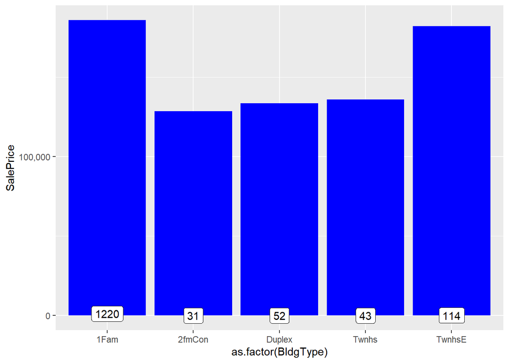

```r
ggplot(all[!is.na(all$SalePrice),], aes(x=as.factor(BldgType), y = SalePrice)) +
  geom_bar(stat = 'summary', fun.y = 'median', fill = 'blue') +
  scale_y_continuous(breaks = seq(0, 800000, by = 100000), labels = comma) +
  geom_label(stat = 'count', aes(label = ..count.., y = ..count..))
```

시각화론 알수가 없다.

```r
# 순서형 범주가 아니기에, factor로 변환한다.
all$BldgType <- as.factor(all$BldgType)
table(all$BldgType)
```

```
##
##   1Fam 2fmCon Duplex  Twnhs TwnhsE
##   2425     62    109     96    227
```

```r
sum(table(all$BldgType))
```

```
## [1] 2919
```

** HouseStyle: 주거의 Style **

```
 1Story   One story
 1.5Fin   One and one-half story: 2nd level finished
 1.5Unf   One and one-half story: 2nd level unfinished
 2Story   Two story
 2.5Fin   Two and one-half story: 2nd level finished
 2.5Unf   Two and one-half story: 2nd level unfinished
 SFoyer   Split Foyer
 SLvl     Split Level
```

```r
# 순서형 범주가 아니기에, factor로 변환한다.
all$HouseStyle <- as.factor(all$HouseStyle)
table(all$HouseStyle)
```

```
##
## 1.5Fin 1.5Unf 1Story 2.5Fin 2.5Unf 2Story SFoyer   SLvl
##    314     19   1471      8     24    872     83    128
```

```r
sum(table(all$HouseStyle))
```

```
## [1] 2919
```

### 4.2.22 Neighborhood and Conditions

물리적 거리, 근방의 입지에 따른 3개의 변수가 있다.

** Neighborhood: 물리적 위치는 ‘Ames’ 시내이다. **

```
 Blmngtn  Bloomington Heights
 Blueste  Bluestem
 BrDale   Briardale
 BrkSide  Brookside
 ClearCr  Clear Creek
 CollgCr  College Creek
 Crawfor  Crawford
 Edwards  Edwards
 Gilbert  Gilbert
 IDOTRR   Iowa DOT and Rail Road
 MeadowV  Meadow Village
 Mitchel  Mitchell
 Names    North Ames
 NoRidge  Northridge
 NPkVill  Northpark Villa
 NridgHt  Northridge Heights
 NWAmes   Northwest Ames
 OldTown  Old Town
 SWISU    South & West of Iowa State University
 Sawyer   Sawyer
 SawyerW  Sawyer West
 Somerst  Somerset
 StoneBr  Stone Brook
 Timber   Timberland
 Veenker  Veenker
```

```r
# 순서형 범주가 아니기에, factor로 변환한다.
all$Neighborhood <- as.factor(all$Neighborhood)
table(all$Neighborhood)
```

```
##
## Blmngtn Blueste  BrDale BrkSide ClearCr CollgCr Crawfor Edwards Gilbert  IDOTRR
##      28      10      30     108      44     267     103     194     165      93
## MeadowV Mitchel   NAmes NoRidge NPkVill NridgHt  NWAmes OldTown  Sawyer SawyerW
##      37     114     443      71      23     166     131     239     151     125
## Somerst StoneBr   SWISU  Timber Veenker
##     182      51      48      72      24
```

```r
sum(table(all$Neighborhood))
```

```
## [1] 2919
```

** Condition1: 근방의 다양한 조건 **

```
 Artery   Adjacent to arterial street
 Feedr    Adjacent to feeder street
 Norm Normal
 RRNn Within 200' of North-South Railroad
 RRAn Adjacent to North-South Railroad
 PosN Near positive off-site feature--park, greenbelt, etc.
 PosA Adjacent to postive off-site feature
 RRNe Within 200' of East-West Railroad
 RRAe Adjacent to East-West Railroad
```

```r
# 순서형 범주가 아니기에, factor로 변환한다.
all$Condition1 <- as.factor(all$Condition1)
table(all$Condition1)
```

```
##
## Artery  Feedr   Norm   PosA   PosN   RRAe   RRAn   RRNe   RRNn
##     92    164   2511     20     39     28     50      6      9
```

```r
sum(table(all$Condition1))
```

```
## [1] 2919
```

** Condition2: 근방의 다양한 조건 (2개 이상) **

```
 Artery   Adjacent to arterial street
 Feedr    Adjacent to feeder street
 Norm Normal
 RRNn Within 200' of North-South Railroad
 RRAn Adjacent to North-South Railroad
 PosN Near positive off-site feature--park, greenbelt, etc.
 PosA Adjacent to postive off-site feature
 RRNe Within 200' of East-West Railroad
 RRAe Adjacent to East-West Railroad
```

```r
# 순서형 범주가 아니기에, factor로 변환한다.
all$Condition2 <- as.factor(all$Condition2)
table(all$Condition2)
```

```
##
## Artery  Feedr   Norm   PosA   PosN   RRAe   RRAn   RRNn
##      5     13   2889      4      4      1      1      2
```

```r
sum(table(all$Condition2))
```

```
## [1] 2919
```

### 4.2.23 Pavement of Street & Driveway

2개의 변수가 있다.

** Street: 부지에 접한 길의 종류**

```
 Grvl Gravel
 Pave Paved
```

```r
# 순서형 범주로, 정수형으로 변환하겠다.
all$Street <- as.integer(revalue(all$Street, c('Grvl' = 0, 'Pave' = 1)))
table(all$Street)
```

```
##
##    0    1
##   12 2907
```

```r
sum(table(all$Street))
```

```
## [1] 2919
```

** PavedDrive: 진입로의 포장 **

```
 Y    Paved
 P    Partial Pavement
 N    Dirt/Gravel
```

```r
#순서형 범주로, 정수형으로 변환하겠다.
all$PavedDrive <- as.integer(revalue(all$PavedDrive, c('N' = 0, 'P' = 1, 'Y' = 2)))
table(all$PavedDrive)
```

```
##
##    0    1    2
##  216   62 2641
```

```r
sum(table(all$PavedDrive))
```

```
## [1] 2919
```

** character형 변수에 대한 인코딩 변환과 설명은 여기까지다 **

3개의 변수를 제외하고 모든 변수들은 결측이 없이 완벽하다. 문자형은 라벨링하여 factor형으로 변환했다. 남은 3개의 변수는 실질적으론 범주형 변수이지만, 형식은 숫자형이다.

### 4.2.24 Year and Month Sold

첨) 여기에서 말하는 경제 위기는 2008년에 있었던 Subprime mortgage 사태를 얘기하는 걸로 보인다.

```r
str(all$YrSold)
```

```
##  int [1:2919] 2008 2007 2008 2006 2008 2009 2007 2009 2008 2008 ...
```

```r
str(all$MoSold)
```

```
##  int [1:2919] 2 5 9 2 12 10 8 11 4 1 ...
```

```r
all$MoSold <- as.factor(all$MoSold)
```

```
## No summary function supplied, defaulting to `mean_se()`
## No summary function supplied, defaulting to `mean_se()`
```

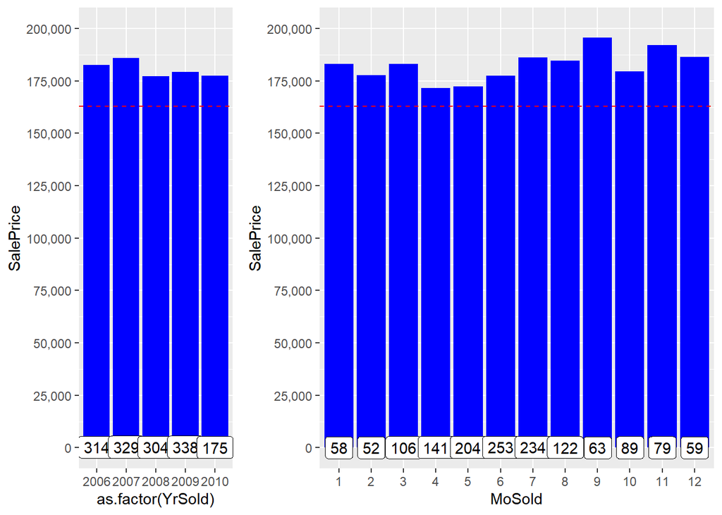

```r
ys <- ggplot(all[!is.na(all$SalePrice),], aes(x = as.factor(YrSold), y = SalePrice)) +
  geom_bar(stat = 'summary', fun.y = 'median', fill = 'blue') +
  scale_y_continuous(breaks = seq(0, 800000, by = 25000), labels = comma) +
  geom_label(stat = 'count', aes(label = ..count.., y = ..count..)) +
  coord_cartesian(ylim = c(0, 200000)) + #y축 20만까지 표기 제한
  geom_hline(yintercept = 163000, linetype='dashed', color = 'red') #SalePrice 중위값
ms <- ggplot(all[!is.na(all$SalePrice),], aes(x = MoSold, y = SalePrice)) +
  geom_bar(stat = 'summary', fun.y = 'median', fill = 'blue') +
  scale_y_continuous(breaks = seq(0, 800000, by = 25000), labels = comma) +
  geom_label(stat = 'count', aes(label = ..count.., y = ..count..)) +
  coord_cartesian(ylim = c(0, 200000)) +
  geom_hline(yintercept = 163000, linetype = 'dashed', color = 'red')
grid.arrange(ys, ms, widths = c(1,2))
```

### 4.2.25 MSSubClass

** MSSubClass: 판매와 연관된 주거 타입 **

```
20  1-STORY 1946 & NEWER ALL STYLES
30  1-STORY 1945 & OLDER
40  1-STORY W/FINISHED ATTIC ALL AGES
45  1-1/2 STORY - UNFINISHED ALL AGES
50  1-1/2 STORY FINISHED ALL AGES
60  2-STORY 1946 & NEWER
70  2-STORY 1945 & OLDER
75  2-1/2 STORY ALL AGES
80  SPLIT OR MULTI-LEVEL
85  SPLIT FOYER
90  DUPLEX - ALL STYLES AND AGES
120  1-STORY PUD (Planned Unit Development) - 1946 & NEWER
150  1-1/2 STORY PUD - ALL AGES
160  2-STORY PUD - 1946 & NEWER
180  PUD - MULTILEVEL - INCL SPLIT LEV/FOYER
190  2 FAMILY CONVERSION - ALL STYLES AND AGES
```

```r
str(all$MSSubClass)
```

```
##  int [1:2919] 60 20 60 70 60 50 20 60 50 190 ...
```

```r
all$MSSubClass <- as.factor(all$MSSubClass)

# 가독성을 높이기 위해 숫자를 문자로 revalue
all$MSSubClass <- revalue(all$MSSubClass, c('20'='1 story 1946+', '30'='1 story 1945-', '40'='1 story unf attic', '45'='1,5 story unf', '50'='1,5 story fin', '60'='2 story 1946+', '70'='2 story 1945-', '75'='2,5 story all ages', '80'='split/multi level', '85'='split foyer', '90'='duplex all style/age', '120'='1 story PUD 1946+', '150'='1,5 story PUD all', '160'='2 story PUD 1946+', '180'='PUD multilevel', '190'='2 family conversion'))

str(all$MSSubClass)
```

```
##  Factor w/ 16 levels "1 story 1946+",..: 6 1 6 7 6 5 1 6 5 16 ...
```

# 5 중요 변수 시각화

모든 문자형 변수를 범주형 factor나, 라벨링하여 숫자형으로 인코딩했다. 더해서, 3개의 수치형 변수는 factor로 변환했고, 1개 변수(Utilities)는 삭제했다. 아래와 같이, 수치형 변수의 수는 이제 56개(종속 변수 포함), 남은 23개 변수는 범주형이다.

```r
numericVars <- which(sapply(all, is.numeric)) # index vector numeric variables
factorVars <- which(sapply(all, is.factor))   # index vector factor variables
cat('There are', length(numericVars), 'numeric variables, and', length(factorVars),
    'categoric variables')
```

```
## There are 56 numeric variables, and 23 categoric variables
```

## 5.1 상관계수 다시 확인

상관 계수를 다시 확인해 보니, 상관 계수 0.5 이상의 변수가 10개에서 16개로 늘었다.

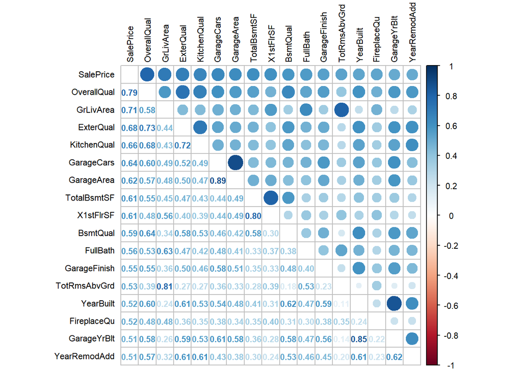

```r
all_numVar <- all[, numericVars]
cor_numVar <- cor(all_numVar, use = 'pairwise.complete.obs') # 모든 수치형 변수의 상관 계수

# SalePrice와 변수들의 상관 계수 내림차순 정렬
cor_sorted <- as.matrix(sort(cor_numVar[, 'SalePrice'], decreasing = TRUE))
# 0.5보다 높은 상관 계수 취사 선택
CorHigh <- names(which(apply(cor_sorted, 1, function(x) abs(x) > 0.5)))
cor_numVar <- cor_numVar[CorHigh, CorHigh]

corrplot.mixed(cor_numVar,
               tl.col = 'black',  # 변수명 색깔
               tl.pos = 'lt',     # 변수명 왼쪽 표시
               tl.cex = 0.7,      # 변수명 text 크기
               cl.cex = 0.7,      # y축 상관계수 text 크기
               number.cex = .7    # matrix안 상관계수 text 크기
               )
```

## 5.2 랜덤포레스트로 변수 중요도 찾기

패키지의 calc.relimp function, boruta function으로 빠르게 선형 회귀 분석을 하여 중요 변수와 그렇지 않은 변수를 그룹핑으로 나누어 연관성있는 중요 변수를 얻을려고 하였으나, 너무 많은 시간이 걸렸다. 100개의 tree만을 써서 깔끔하진 못하지만 빠른 Random Forest 모델을 간략하게 사용하기로 했다. (변수의 중요성에 대한 시사만 얻음)

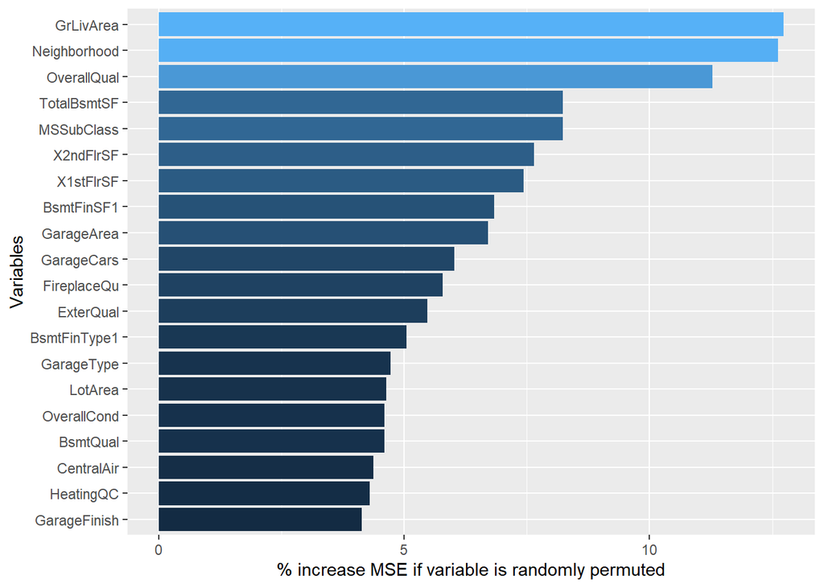

```r
set.seed(2022) #인수 '2022'로 시드 생성
quick_RF <- randomForest(x = all[1:1460, -79], y = all$SalePrice[1:1460], ntree = 100, importance = TRUE)
imp_RF <- importance(quick_RF)
imp_DF <- data.frame(Variables = row.names(imp_RF), MSE = imp_RF[,1])
imp_DF <- imp_DF[order(imp_DF$MSE, decreasing = TRUE),]

ggplot(imp_DF[1:20,],
       aes(x = reorder(Variables, MSE), y = MSE, fill = MSE)) + # MSE기준 변수 재정렬
       geom_bar(stat = 'identity') +
       labs(x = 'Variables', y = '% increase MSE if variable is randomly permuted') + #x,y축명 명명
       coord_flip() + #x, y축 반전
       theme(legend.position = 'none')
```

가장 중요한 변수중 3개만이 범주형이다. ‘Neighborhood’, ‘MSSubClass’, ‘GarageType’

### 5.2.1 Above Ground Living Area, and other surface related variables (in square feet)

처음 데이터를 볼 때 Above Ground Living Area와 SalePrice 변수간의 연관성은 이미 확인했지만, 그 분포를 다시 나타내겠다. 이번 섹션에서 ‘Square feet’ 연관 변수중 측정된 상위 20개의 값으로 번들을 만들겠다.

‘Total Rooms Above Ground(TotRmsAbvGrd)’ 변수 또한 Above Ground Living Area와 높은 상관 관계(0.81)를 보이기에 더해서 나타낸다.

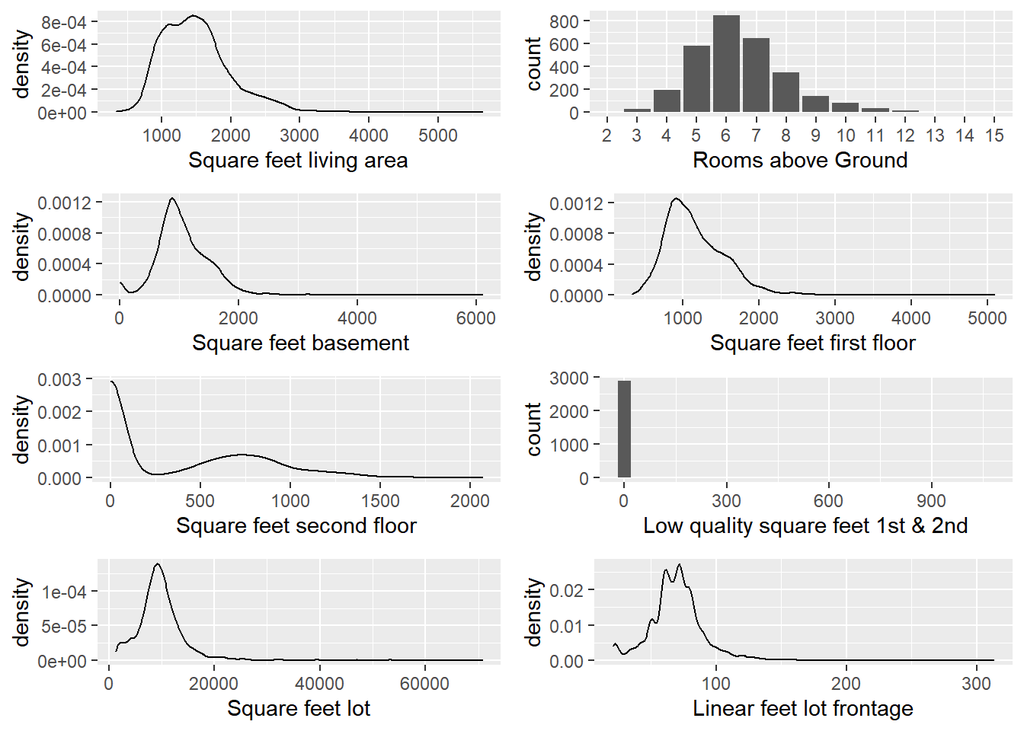

```r
s1 <- ggplot(data = all, aes(x = GrLivArea)) +
  geom_density() + labs(x = 'Square feet living area')
s2 <- ggplot(data = all, aes(x = as.factor(TotRmsAbvGrd))) +
  geom_histogram(stat = 'count') + labs(x = 'Rooms above Ground')
s3 <- ggplot(all, aes(x = X1stFlrSF)) +
  geom_density() + labs(x = 'Square feet first floor')
s4 <- ggplot(all, aes(x = X2ndFlrSF)) +
  geom_density() + labs(x = 'Square feet second floor')
s5 <- ggplot(all, aes(x = TotalBsmtSF)) +
  geom_density()+ labs(x = 'Square feet basement')
s6 <- ggplot(all[all$LotArea < 100000,], aes(x = LotArea)) +
  geom_density() + labs(x = 'Square feet lot')
s7 <- ggplot(all, aes(x = LotFrontage)) +
  geom_density() + labs(x = 'Linear feet lot frontage')
s8 <- ggplot(all, aes(x = LowQualFinSF)) +
  geom_histogram() + labs(x = 'Low quality square feet 1st & 2nd')

layout <- matrix(c(1,2,5,3,4,8,6,7),4,2, byrow = TRUE) # 4행 2열 ()안의 순으로 행부터 matrix 생성
multiplot(s1, s2, s3, s4, s5, s6, s7, s8, layout = layout)
```

lot 시각화를 위해 이미 10만 평방 미터 이상의 4채를 제거했다. GrLivArea는 1,2층 평방 피트의 합계인 것 같다. 그러나, 뒤에 있는 차트에서 LowQualFinSF라는 다른 이름의 변수를 찾았다. 이건 모든 층이 저품질로 완료된 평방 피트이다. ’Low quality square feet 1st and 2nd’를 보는 바와 같이 40채를 제외하고 거의 모든 집이 해당되지 않는다. 이 평방 피트는 실제적으로 GrLivArea에 포함되어 있다. GrLivArea와 3개 변수간의 상관계수는 정확하게 1이다.

```r
cor(all$GrLivArea, (all$X1stFlrSF + all$X2ndFlrSF + all$LowQualFinSF))
```

```
## [1] 1
```

```r
head(all[all$LowQualFinSF > 0, c('GrLivArea', 'X1stFlrSF', 'X2ndFlrSF', 'LowQualFinSF')])
```

```
##     GrLivArea X1stFlrSF X2ndFlrSF LowQualFinSF
## 52       1176       816         0          360
## 89       1526      1013         0          513
## 126       754       520         0          234
## 171      1382       854         0          528
## 186      3608      1518      1518          572
## 188      1656       808       704          144
```

### 5.2.2 The most important categorical variables; Neighborhood

처음의 그래프는 Neighborhood의 SalePrice 중위값을 보여준다.

train data 기준 각각의 동네에 따른 집의 개수를 라벨링하였다.(test data엔 SalePrice가 결측치.)

두 번째 그래프는 all data 기준 Neighborhood에 따른 집의 개수를 라벨링하였다.

```
## No summary function supplied, defaulting to `mean_se()`
```

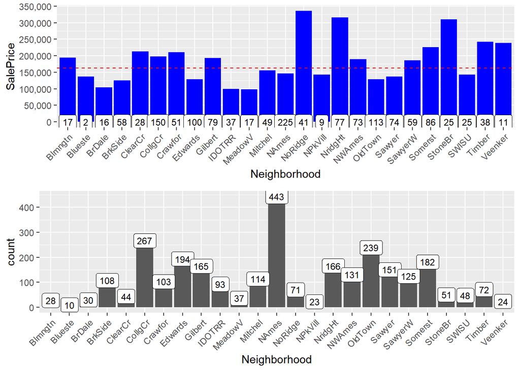

```r
n1 <- ggplot(all[!is.na(all$SalePrice),], aes(x = Neighborhood, y = SalePrice)) +
  geom_bar(stat = 'summary', fun.y = 'median', fill = 'blue') +
  theme(axis.text.x = element_text(angle = 45, hjust = 1)) +
  scale_y_continuous(breaks = seq(0, 800000, by = 50000), labels = comma) +
  geom_label(stat = 'count', aes(label = ..count.., y = ..count..), size = 3) +
  geom_hline(yintercept = 163000, linetype = 'dashed', color = 'red') #점선은 판매가 중위값

n2 <- ggplot(all, aes(x = Neighborhood)) +
  geom_histogram(stat = 'count') +
  geom_label(stat = 'count', aes(label = ..count.., y = ..count..), size = 3) +
  theme(axis.text.x = element_text(angle = 45, hjust = 1))
grid.arrange(n1, n2)
```

### 5.2.3 Overall Quality, and other Quality variables

처음 데이터를 볼 때 Overall Quality와 SalePrice 변수간의 관계성은 이미 시각화했지만, 빈도 분포도 나타내고 싶다.  
이번 섹션에선 다른 Quality들도 번들로 묶어 나타내겠다.

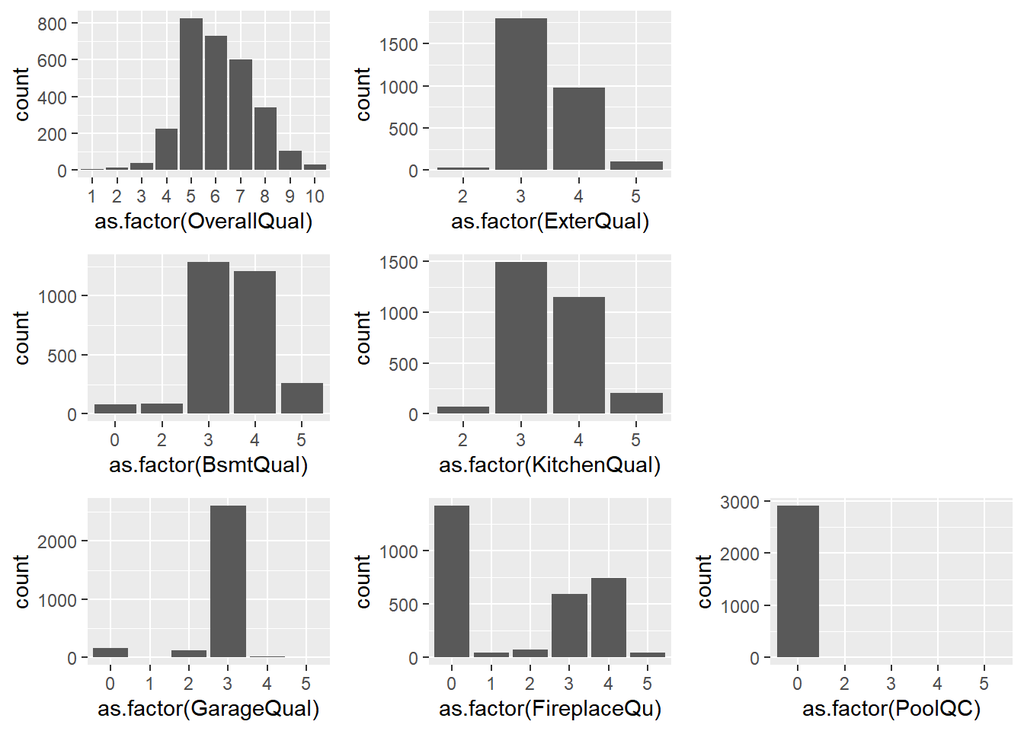

```r
q1 <- ggplot(all, aes(x = as.factor(OverallQual))) +
  geom_histogram(stat = 'count')
q2 <- ggplot(all, aes(x = as.factor(ExterQual))) +
  geom_histogram(stat = 'count')
q3 <- ggplot(all, aes(x = as.factor(BsmtQual))) +
  geom_histogram(stat = 'count')
q4 <- ggplot(all, aes(x = as.factor(KitchenQual))) +
  geom_histogram(stat = 'count')
q5 <- ggplot(all, aes(x = as.factor(GarageQual))) +
  geom_histogram(stat = 'count')
q6 <- ggplot(all, aes(x = as.factor(FireplaceQu))) +
  geom_histogram(stat = 'count')
q7 <- ggplot(all, aes(x = as.factor(PoolQC))) +
  geom_histogram(stat = 'count')

layout <- matrix(c(1,2,8,3,4,8,5,6,7),3,3, byrow = TRUE) #3행 3열 matrix
multiplot(q1, q2, q3, q4, q5, q6, q7, layout = layout)
```

Overall Quality는 아주 중요하고 다른 변수들보다 범주가 많다. External Quality 또한 중요하지만 Overall Quality와 상관 계수가 높다.(0.73) Kitchen Quality는 범주마다 약간의 차이는 있지만 모든 집이 주방이 있다는 걸 보여준다. Garage Quality는 대부분이 Q3에 몰려 있어 구분이 쉽지 않다. Fireplace Quality는 높은 상관 계수 항목과 중요한 변수 항목안에 있다. PoolQC는 매우 드물다.(이 규모에선 13개 풀은 보이지조차 않는다.) 나중에 pool 유무를 변수로 만들겠다.

### 5.2.4 The second most important categoriacal variables; MSSubClass

첫 번째 차트는 MSSubClass의 SalePrice 중위값을 시각화한 것이다. train data 기준 각각의 MsSubClass에 따른 집의 개수를 라벨링하였다. 히스토그램은 all data 기준 MSSubClass에 따른 집의 개수를 라벨링하였다. 대다수의 집은 상대적으로 신축이며, 1개 또는 2개의 이야기를 가진다.

```
## No summary function supplied, defaulting to `mean_se()`
```

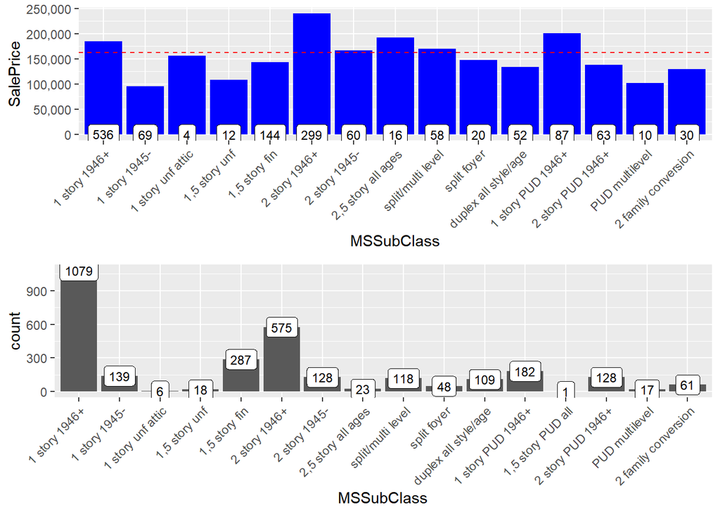

```r
ms1 <- ggplot(all[!is.na(all$SalePrice),], aes(x = MSSubClass, y = SalePrice)) +
  geom_bar(stat = 'summary', fun.y = 'median', fill = 'blue') +
  theme(axis.text.x = element_text(angle = 45, hjust = 1)) +
  scale_y_continuous(breaks = seq(0, 800000, by = 50000), labels = comma) +
  geom_label(stat = 'count', aes(label = ..count.., y = ..count..), size = 3) +
  geom_hline(yintercept = 163000, linetype = 'dashed', color = 'red') #점선은 판매가 중위값

ms2 <- ggplot(all, aes(x = MSSubClass)) +
  geom_histogram(stat = 'count') +
  geom_label(stat = 'count', aes(label = ..count.., y = ..count..), size = 3) +
  theme(axis.text.x = element_text(angle = 45, hjust = 1))
grid.arrange(ms1, ms2)
```

### 5.2.5 Garage variables

몇 몇 Garage 변수는 SalePrice와 높은 상관 관계를 가지고 있고, quick random forest의 top20 리스트에도 들어 있다. 그러나 그들간에 다중 공선성이 있고, 7개 Garage 변수는 너무 많아 보인다. ‘GarageCars’, ‘GarageType’과 ’Quality 측정 변수’ 중 하나, 이렇게 3개면 충분하다고 생각한다. 그럼에도 3개를 선별하기 전에 일단 7개를 모두 시각화하겠다.

```r
# 오탈자 수정
all$GarageYrBlt[2593] <- 2007 # GarageYrBlt=2207, YearBuilt = 2006, YearRemodAdd= 2007.
# data가 잘못 입력된 data이다. 주최측에서 실수가 있었던것 같다. 재건축 년도 기준으로 맞추겠다.
```

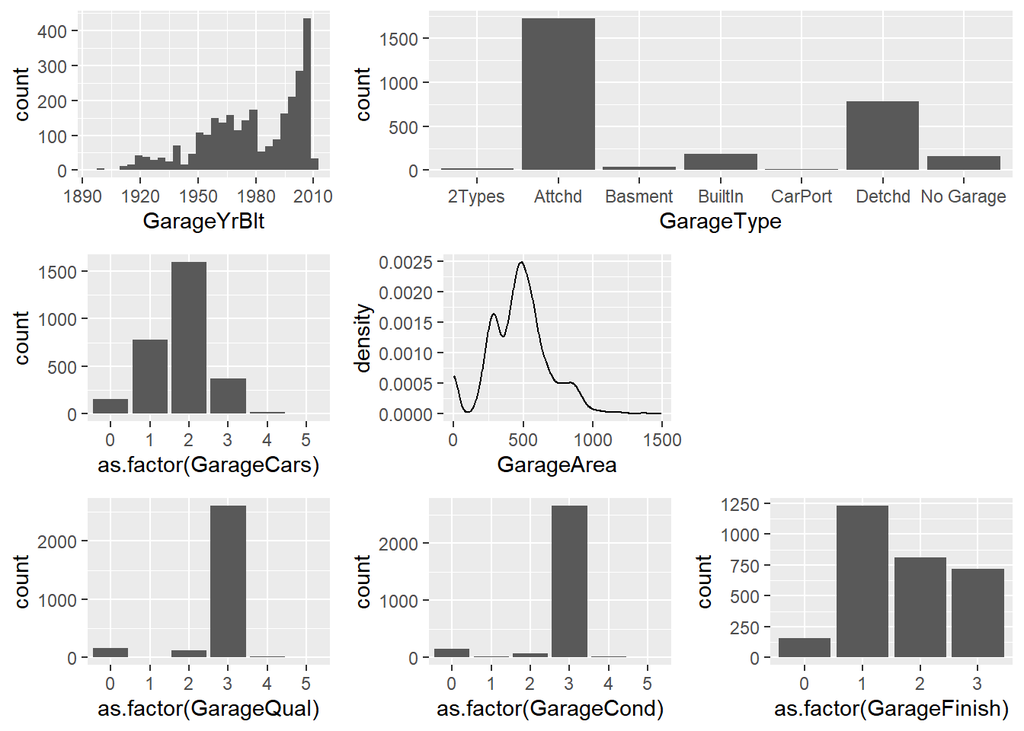

```r
g1 <- ggplot(all[all$GarageCars !=0,], aes(x = GarageYrBlt)) +
  geom_histogram()
g2 <- ggplot(all, aes(x = as.factor(GarageCars))) +
  geom_histogram(stat = 'count')
g3 <- ggplot(all, aes(x = GarageArea)) +
  geom_density()
g4 <- ggplot(all, aes(x = as.factor(GarageCond))) +
  geom_histogram(stat = 'count')
g5 <- ggplot(all, aes(x = GarageType)) +
  geom_histogram(stat = 'count')
g6 <- ggplot(all, aes(x = as.factor(GarageQual))) +
  geom_histogram(stat = 'count')
g7 <- ggplot(all, aes(x = as.factor(GarageFinish))) +
  geom_histogram(stat = 'count')

layout <- matrix(c(1,5,5,2,3,8,6,4,7),3,3, byrow = TRUE)
multiplot(g1, g2, g3, g4, g5, g6, g7, layout = layout)
```

4.2 섹션에서 이미 설명을 했듯이 GarageCars와 GarageArea는 높은 상관 관계를 가진다. 여기에선 GarageQual과 GarageCond 역시 높은 상관 관계를 가지는 걸로 보이고, 3레벨의 개수가 가장 많다.

### 5.2.6 Basement variables

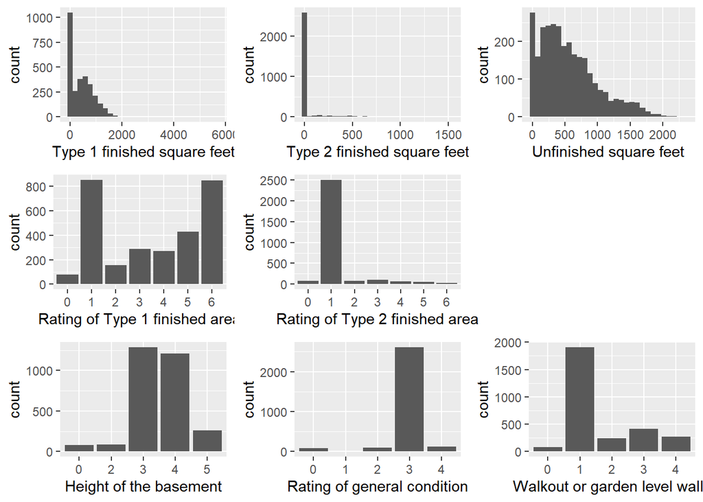

```r
b1 <- ggplot(all, aes(x = BsmtFinSF1)) +
  geom_histogram() + labs(x = 'Type 1 finished square feet')
b2 <- ggplot(all, aes(x = BsmtFinSF2)) +
  geom_histogram() + labs(x = 'Type 2 finished square feet')
b3 <- ggplot(all, aes(x = BsmtUnfSF)) +
  geom_histogram() + labs(x = 'Unfinished square feet')
b4 <- ggplot(all, aes(x = as.factor(BsmtFinType1))) +
  geom_histogram(stat = 'count') + labs(x = 'Rating of Type 1 finished area')
b5 <- ggplot(all, aes(x = as.factor(BsmtFinType2))) +
  geom_histogram(stat = 'count') + labs(x = 'Rating of Type 2 finished area')
b6 <- ggplot(all, aes(x = as.factor(BsmtQual))) +
  geom_histogram(stat = 'count') + labs(x = 'Height of the basement')
b7 <- ggplot(all, aes(x = as.factor(BsmtCond))) +
  geom_histogram(stat = 'count') + labs(x = 'Rating of general condition')
b8 <- ggplot(all, aes(x = as.factor(BsmtExposure))) +
  geom_histogram(stat = 'count') + labs(x = 'Walkout or garden level walls')

layout <- matrix(c(1,2,3,4,5,9,6,7,8),3,3, byrow= TRUE)
multiplot(b1, b2, b3, b4, b5, b6, b7, b8, layout = layout)
```

보는 바와 같이 ‘TotalBsmtSF’ 변수의 총 지하 면적이 완료 영역(2가지 이상의 유형이 있는 경우 2개) & 미완 영역으로 세분화 된 것 처럼 보인다. 3 변수(BsmtFinSF1, SF2, UnfSf)와 TotalBsmtSf 간의 상관 계수를 확인해보자 그 상관 계수는 정확하게 1이다. 에러도 작은 차이도 없는 멋진 수치다!

Basement Quality는 지하실 높이를 구체적으로 평가한다는 점에서 혼란을 주는 변수 명이다.

# 6 Feature engineering

## 6.1 Total number of Bathrooms

4개의 Bathroom 관련 변수는 개별적으론 그다지 중요하지 않아 보인다. 하지만, 만약 여기에 하나의 독립 변수를 추가한다면 그건 아주 강력한 요인이 될 것이다

파우더룸이나 게스트용 Bath로 알려진 ‘half-bath’, 여기엔 욕실의 주요 구성 요소 4개 중 2개만이 있다. (화장실과 싱크대) 결론적으로, half bathroom을 0.5로 정해서 계산할 것이다.

```r
all$ToBathrooms <- all$FullBath + (all$HalfBath*0.5) + all$BsmtFullBath + (all$BsmtHalfBath*0.5)
```

첫 번째 그래프에서 보이듯이, 추가한 변수는 깔끔한 0.63의 상관 계수를 보인다. 두 번째 그래프는 all data기준, Bathroom의 개수 분포를 나타낸다.

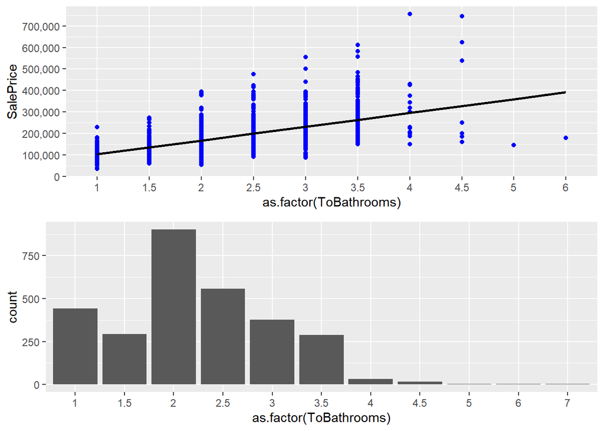

```r
tb1 <- ggplot(all[!is.na(all$SalePrice),], aes(x = as.factor(ToBathrooms), y = SalePrice)) +
  geom_point(col = 'blue') +
  geom_smooth(method = 'lm', se = FALSE, color = 'black', aes(group = 1)) +
  scale_y_continuous(breaks = seq(0, 800000, by = 100000), labels = comma)
tb2 <- ggplot(all, aes(x = as.factor(ToBathrooms))) +
  geom_histogram(stat = 'count')
grid.arrange(tb1, tb2)
```

## 6.2 Adding ‘House Age’, ‘Remodeled (Yes/No)’, and IsNew Variables

집의 년수와 관련된 3개의 변수가 있다. ‘YearBlt’, ‘YearRemodAdd’, ‘YearSold’ 증축/리모델링을 하지 않을 시 ’YearRemodAdd’는 ’YearBuilt’의 값으로 기본 설정된다. 년수를 결정하기 위해 ’YearRemodeled’와 ’YearSold’를 쓸 것이다. 그러나, 오래된 구조물의 일부가 남아있고, 집의 일부만 개조되었을 수 있으므로 리모델링 유무 변수에 흥미가 간다. 만약 건축 년수가 리모델링 날짜에 기반한다면 이건 패널티 변수로 보아야 한다. 그건 아마도 같은 해에 신축된 건물보다 가치가 낮을 것이기 때문이다.

```r
all$Remod <- ifelse(all$YearBuilt==all$YearRemodAdd, 0, 1) # 0 = 'No remodeling', 1 = 'remodeling'
all$Age <- as.numeric(all$YrSold)-all$YearRemodAdd
```

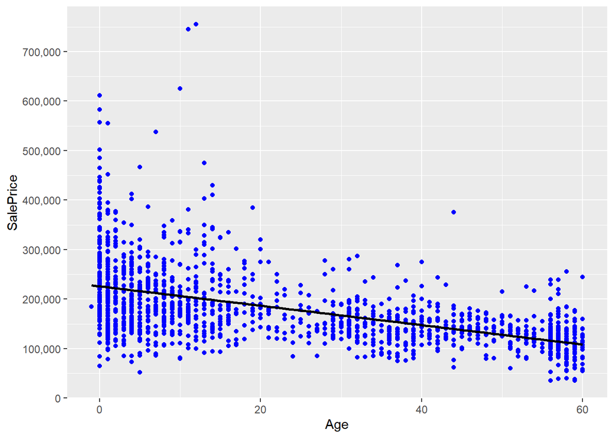

```r
ggplot(all[!is.na(all$SalePrice),], aes(x = Age, y = SalePrice)) +
  geom_point(col = 'blue') +
  geom_smooth(method = 'lm', se = FALSE, color = 'black', aes(group = 1)) +
  scale_y_continuous(breaks = seq(0, 800000, by = 100000), labels = comma)
```

예상대로 그래프는 년수와 판매 가격간 음의 상관 관계를 보여준다.(오래된 집은 가치가 낮다.)

```r
cor(all$SalePrice[!is.na(all$SalePrice)], all$Age[!is.na(all$SalePrice)])
```

```
## [1] -0.5090787
```

아래와 같이 예상대로 리모델링 건물은 그렇지 않은 건물보다 가치가 떨어진다.

```
## No summary function supplied, defaulting to `mean_se()`
```

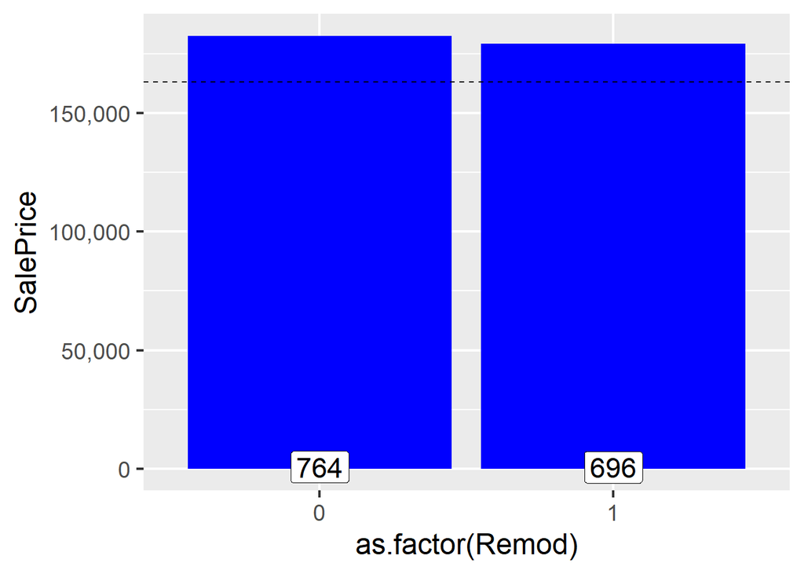

```r
ggplot(all[!is.na(all$SalePrice),], aes(x = as.factor(Remod), y = SalePrice)) +
  geom_bar(stat = 'summary', fun.y = 'median', fill = 'blue') +
  geom_label(stat = 'count', aes(label = ..count.., y = ..count..), size = 6) +
  scale_y_continuous(breaks = seq(0, 800000, by = 50000), labels = comma) +
  theme_grey(base_size = 18) +
  geom_hline(yintercept = 163000, linetype = 'dashed') # 점선은 판매가의 중위값
```

마지막으로, 아래와 같이 IsNew 변수를 만들겠다. 데이터셋 안에 116채의 집이 새 집이다.

```r
all$IsNew <- ifelse(all$YrSold==all$YearBuilt, 1, 0) #판매 년도와 건축 년도가 같으면 1, 아니면 0
table(all$IsNew)
```

```
##
##    0    1
## 2803  116
```

이 116채의 새 집은 train과 test 셋에 공평하게 분배되고, 보는 바와 같이 새 집들은 평균보다 훨씬 가치가 있다.

```
## No summary function supplied, defaulting to `mean_se()`
```

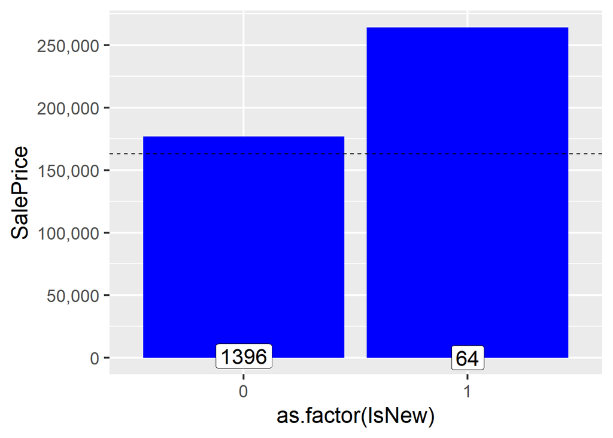

```r
ggplot(all[!is.na(all$SalePrice),], aes(x = as.factor(IsNew), y = SalePrice)) +
  geom_bar(stat = 'summary', fun.y = 'median', fill = 'blue') +
  geom_label(stat = 'count', aes(label = ..count.., y = ..count..), size =6) +
  scale_y_continuous(breaks = seq(0, 800000, by = 50000), labels = comma) +
  theme_grey(base_size = 18) +
  geom_hline(yintercept = 163000, linetype = 'dashed') # 점선은 판매가의 중위값
```

```r
all$YrSold <- as.factor(all$YrSold) # numeric 변수 버전은 더이상 필요하지 않다.
```

## 6.3 Binning Neighborhood

```
## No summary function supplied, defaulting to `mean_se()`
## No summary function supplied, defaulting to `mean_se()`
```

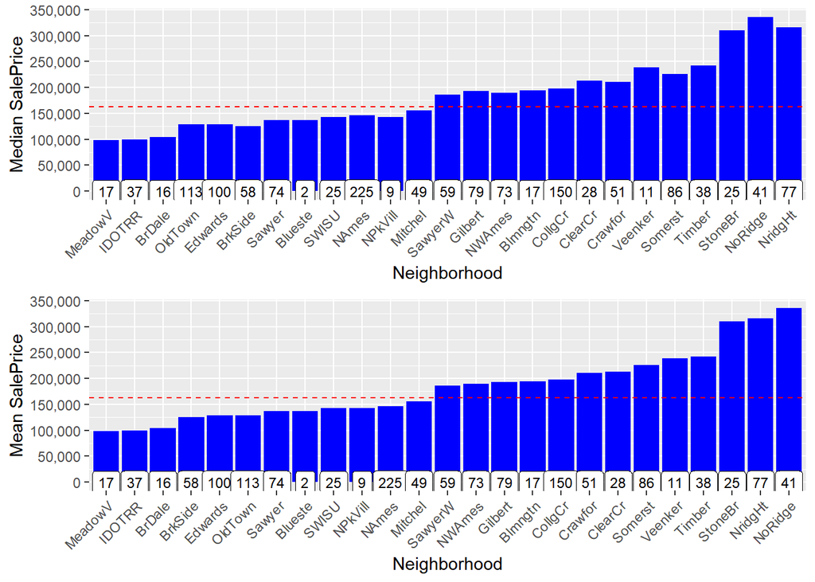

```r
nb1 <- ggplot(all[!is.na(all$SalePrice),],
              aes(x = reorder(Neighborhood, SalePrice, FUN = median), y = SalePrice)) +
  geom_bar(stat = 'summary', fun.y = 'median', fill = 'blue') +
  labs(x = 'Neighborhood', y = 'Median SalePrice') +
  theme(axis.text.x = element_text(angle = 45, hjust = 1)) +
  scale_y_continuous(breaks = seq(0, 800000, by = 50000), labels = comma) +
  geom_label(stat = 'count', aes(label = ..count.., y = ..count..), size = 3) +
  geom_hline(yintercept = 163000, linetype = 'dashed', color = 'red') #점선은 판매가의 중위값
nb2 <- ggplot(all[!is.na(all$SalePrice),],
              aes(x = reorder(Neighborhood, SalePrice, FUN = mean), y = SalePrice)) +
  geom_bar(stat = 'summary', fun.y = 'mean', fill = 'blue') +
  labs(x = 'Neighborhood', y = 'Mean SalePrice') +
  theme(axis.text.x = element_text(angle = 45, hjust = 1)) +
  scale_y_continuous(breaks = seq(0, 800000, by = 50000), labels = comma ) +
  geom_label(stat = 'count', aes(label = ..count.., y = ..count..), size = 3) +
  geom_hline(yintercept = 163000, linetype = 'dashed', color = 'red') #점선은 판매가의 중위값
grid.arrange(nb1, nb2)
```

대체적으로 판매가가 높은 3 동네는 중위값과 평균의 순위 역시 높게 보인다. 상대적으로 제일 열악한 3곳의 동네에서의 양쪽 그래프 역시 같게 보인다. ’overbin’하고 싶지 않기 때문에, 극단에 해당하는 범주만 만들겠다.

```r
all$NeighRich[all$Neighborhood %in% c('StoneBr', 'NridgHt', 'NoRidge')] <- 2
all$NeighRich[!all$Neighborhood %in% c('MeadowV', 'IDOTRR', 'BrDale', 'StoneBr', 'NridgHt', 'NoRidge')] <- 1
all$NeighRich[all$Neighborhood %in% c('MeadowV', 'IDOTRR', 'BrDale')] <- 0
```

```r
table(all$NeighRich)
```

```
##
##    0    1    2
##  160 2471  288
```

## 6.4 Total Square Feet

사람들이 집을 살 때 일반적으로 총 거주 공간은 아주 중요하다. 지상 + 지하의 공간을 더해 독립 변수를 만들겠다.

```r
all$TotalSqFeet <- all$GrLivArea + all$TotalBsmtSF
```

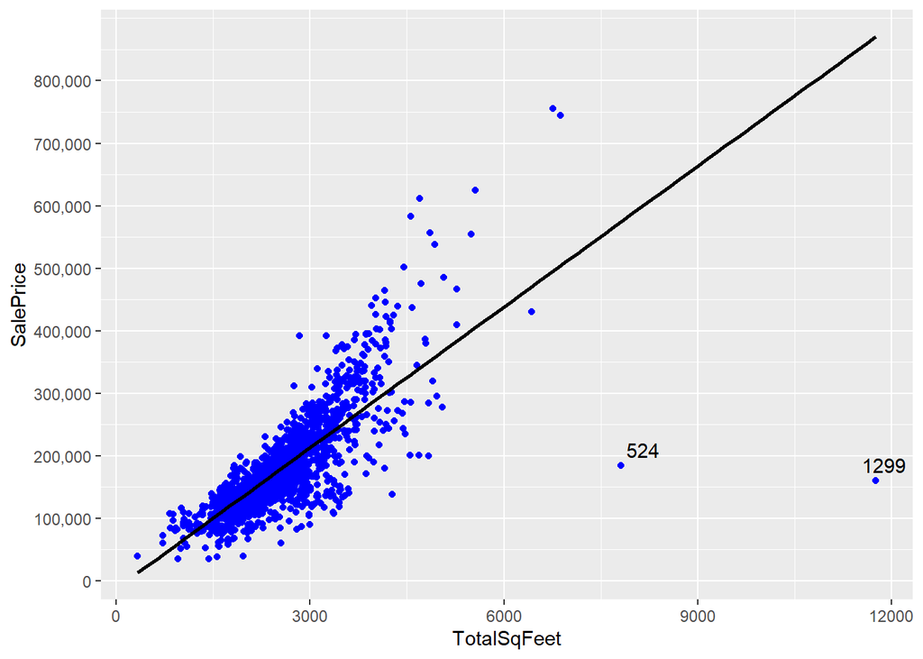

```r
ggplot(all[!is.na(all$SalePrice),], aes(x = TotalSqFeet, y = SalePrice)) +
  geom_point(col = 'blue') +
  geom_smooth(method = 'lm', se = FALSE, color = 'black', aes(group = 1)) +
  scale_y_continuous(breaks = seq(0, 800000, by = 100000), labels = comma) +
  geom_text_repel(aes(label = ifelse(all$GrLivArea[!is.na(all$SalePrice)] > 4500, rownames(all), '')))
```

예상한 바와 같이 판매가와의 상관 관계는 아주 강력하다(0.78)

```r
cor(all$SalePrice, all$TotalSqFeet, use = 'pairwise.complete.obs') #결측치있는 case 제거한 상관계수 계산
```

```
## [1] 0.7789588
```

두 개의 잠재적인 이상치는 이전보다 더 극단적으로 보인다. 두 이상치를 제거하면 상관 계수가 5% 증가할 것이다.

```r
cor(all$SalePrice[-c(524, 1299)], all$TotalSqFeet[-c(524, 1299)], use = 'pairwise.complete.obs')
```

```
## [1] 0.829042
```

## 6.5 Consolidating Porch variables

아래와 같이, 현관(Porch)과 관련된 변수들을 리스트했다.

- WoodDeckSF: Wood deck area in square feet
- OpenPorchSF: Open porch area in square feet
- EnclosedPorch: Enclosed porch area in square feet
- 3SsnPorch: Three season porch area in square feet
- ScreenPorch: Screen porch area in square feet

내가 아는 한, 현관은 집 외부의 보호구역이고, Wooden deck은 보호가 되지 않는다. 따라서, Wooden deck은 제외하고 4개 변수만을 고려하겠다.

```r
all$TotalPorchSF <- all$OpenPorchSF + all$EnclosedPorch + all$X3SsnPorch + all$ScreenPorch
```

이런 현관 영역을 합산하는 것은 의미가 있지만(영역간에 겹쳐서는 안된다) 판매가와의 그 상관 관계는 높지 않다.

```r
cor(all$SalePrice, all$TotalPorchSF, use = 'pairwise.complete.obs')
```

```
## [1] 0.1957389
```

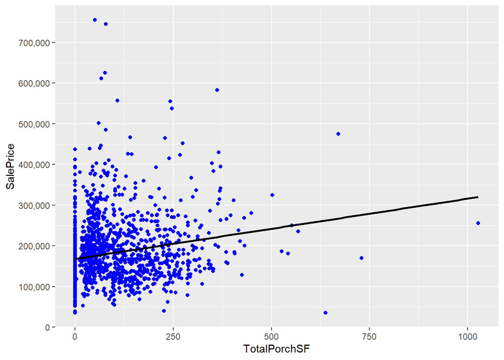

```r
ggplot(all[!is.na(all$SalePrice),], aes(x = TotalPorchSF, y = SalePrice)) +
  geom_point(col = 'blue') +
  geom_smooth(method = 'lm', se=FALSE, color = 'black', aes(group = 1)) +
  scale_y_continuous(breaks = seq(0, 800000, by = 100000), labels = comma)
```

# 7 모델링을 위한 데이터 준비

## 7.1 상관관계 높은 변수 삭제

```r
dropVars <- c('YearRemodAdd', 'GarageYrBlt', 'GarageArea', 'GarageCond', 'TotalBsmtSF', 'TotalRmsAbvGrd', 'BsmtFinSF1')

all <- all[,!(names(all) %in% dropVars)]
```

## 7.2 이상치 제거

```r
all <- all[-c(524, 1299), ]
```

## 7.3 예측변수 사전처리

모델링 전에 라벨링 인코딩하지 않은 숫자형 독립 변수를 조정한다. 그리고 범주형 독립 변수를 위해 더미 변수를 만든다. 모든 숫자형 독립 변수와 범주형 변수를 데이터프레임으로 분할한다.

```r
numericVarNames <- numericVarNames[!(numericVarNames %in% c('MSSubClass', 'MoSold', 'YrSold', 'SalePrice', 'OverallQual', 'OverallCond'))] #numericVarNames 작업 완료전 변수 생성
numericVarNames <- append(numericVarNames, c('Age', 'TotalPorchSF', 'TotBathrooms', 'TotalSqFeet'))

DFnumeric <- all[, names(all) %in% numericVarNames]

DFfactors <- all[, !(names(all) %in% numericVarNames)]
DFfactors <- DFfactors[, names(DFfactors) != 'SalePrice']

cat('There are', length(DFnumeric), 'numeric variables, and', length(DFfactors), 'factor variables')
```

```
## There are 29 numeric variables, and 50 factor variables
```

### 7.3.1 numeric predictors의 왜도 및 정규화

Skewness(왜곡)는 분포에서 대칭을 측정한 것이다. 대칭 데이터셋의 왜곡은 0이다. 그래서, 정규 분포는 왜곡이 0일 것이다. 왜곡은 원래 양측 꼬리의 상대적 크기를 측정한다.  
왜곡은 -1과 1 사이이다. 이 범위에서, 데이터는 상당히 대칭적인 것으로 간주된다.  
왜곡을 수정하려면, 모든 숫자형 독립 변수와 0.8(실질적으로 log+1, 제로 이슈로 인한 분열을 피하기 위해)보다 큰 absolute skew의 로그를 가져와야 한다.

```r
for(i in 1:ncol(DFnumeric)){
        if (abs(skew(DFnumeric[,i])) > 0.8){
                DFnumeric[,i] <- log(DFnumeric[,i] +1)
        }
}
```

** 데이터 정규화 **

```r
PreNum <- preProcess(DFnumeric, method=c('center', 'scale')) #'center', 'scale' preProcessing후 변수 생성
print(PreNum)
```

```
## Created from 2917 samples and 29 variables
##
## Pre-processing:
##   - centered (29)
##   - ignored (0)
##   - scaled (29)
```

```r
DFnorm <- predict(PreNum, DFnumeric)
dim(DFnorm)
```

```
## [1] 2917   29
```

### 7.3.2 One hot encoding the categorical variables

마지막으로, 최상의 머신러닝 알고리즘을 위해 모든 독립 변수를 ‘one-hot encode’ 하여 범주형 변수를 숫자 컬럼으로 변환하겠다. 즉, model.matrix()함수를 써서 범주형 값을 1과 0으로 컬럼을 분리하겠다.(1은 Yes)

```r
DFdummies <- as.data.frame(model.matrix(~.-1, DFfactors))
dim(DFdummies)
```

```
## [1] 2917  202
```

### 7.3.3 Removing levels with few or no observation in train or test

이전 버전에서, ‘Caret’패키지의 ’Near Zero Variance’ 함수를 썻다. 이건 빠르지만, 정보의 손실이 너무 크다. 이걸 기본으로 설정하여 ’one-hot encode’하면 모든 동네에서 최소 146채의 주택 변수가 생략된다. 따라서, 이 버전에서 조심스러운 접근법을 택했다.

```r
# test셋에 없는 변수가 있는지 확인
ZerocolTest <- which(colSums(DFdummies[(nrow(all[!is.na(all$SalePrice),])+1):nrow(all),])==0)
colnames(DFdummies[ZerocolTest])
```

```
##  [1] "Condition2RRAe"     "Condition2RRAn"     "Condition2RRNn"
##  [4] "HouseStyle2.5Fin"   "RoofMatlMembran"    "RoofMatlMetal"
##  [7] "RoofMatlRoll"       "Exterior1stImStucc" "Exterior1stStone"
## [10] "Exterior2ndOther"   "HeatingOthW"        "ElectricalMix"
## [13] "MiscFeatureTenC"
```

```r
DFdummies <- DFdummies[,-ZerocolTest] # 예측 변수 제거
```

```r
# train셋에 없는 변수가 있는지 확인
ZerocolTrain <- which(colSums(DFdummies[1:nrow(all[!is.na(all$SalePrice),]),])==0)
colnames(DFdummies[ZerocolTrain])
```

```
## [1] "MSSubClass1,5 story PUD all"
```

```r
DFdummies <- DFdummies[,-ZerocolTrain] #예측 변수 제거
```

train 셋에서 10 미만의 값을 갖는 변수를 추출

```r
fewOnes <- which(colSums(DFdummies[1:nrow(all[!is.na(all$SalePrice),]),]) < 10)
colnames(DFdummies[fewOnes])
```

```
##  [1] "MSSubClass1 story unf attic" "LotConfigFR3"
##  [3] "NeighborhoodBlueste"         "NeighborhoodNPkVill"
##  [5] "Condition1PosA"              "Condition1RRNe"
##  [7] "Condition1RRNn"              "Condition2Feedr"
##  [9] "Condition2PosA"              "Condition2PosN"
## [11] "RoofStyleMansard"            "RoofStyleShed"
## [13] "RoofMatlWdShake"             "RoofMatlWdShngl"
## [15] "Exterior1stAsphShn"          "Exterior1stBrkComm"
## [17] "Exterior1stCBlock"           "Exterior2ndAsphShn"
## [19] "Exterior2ndBrk Cmn"          "Exterior2ndCBlock"
## [21] "Exterior2ndStone"            "FoundationStone"
## [23] "FoundationWood"              "HeatingGrav"
## [25] "HeatingWall"                 "ElectricalFuseP"
## [27] "GarageTypeCarPort"           "MiscFeatureOthr"
## [29] "SaleTypeCon"                 "SaleTypeConLD"
## [31] "SaleTypeConLI"               "SaleTypeConLw"
## [33] "SaleTypeCWD"                 "SaleTypeOth"
## [35] "SaleConditionAdjLand"
```

```r
DFdummies <- DFdummies[,-fewOnes] #예측 변수 제거
dim(DFdummies)
```

```
## [1] 2917  153
```

변수가 적거나 없는 독립 변수 49개를 ’one-hot encode’하여 지우겠다. 개수가 많아 보이지만, 실제로는 caret’s의 near zero variance 함수를 써서 지운 변수보다 개수가 적다.

```r
combined <- cbind(DFnorm, DFdummies) # 컬럼 결합으로 데이터프레임 생성
```

## 7.4 Dealing with skewness of response variable

```r
skew(all$SalePrice)
```

```
## [1] 1.877427
```

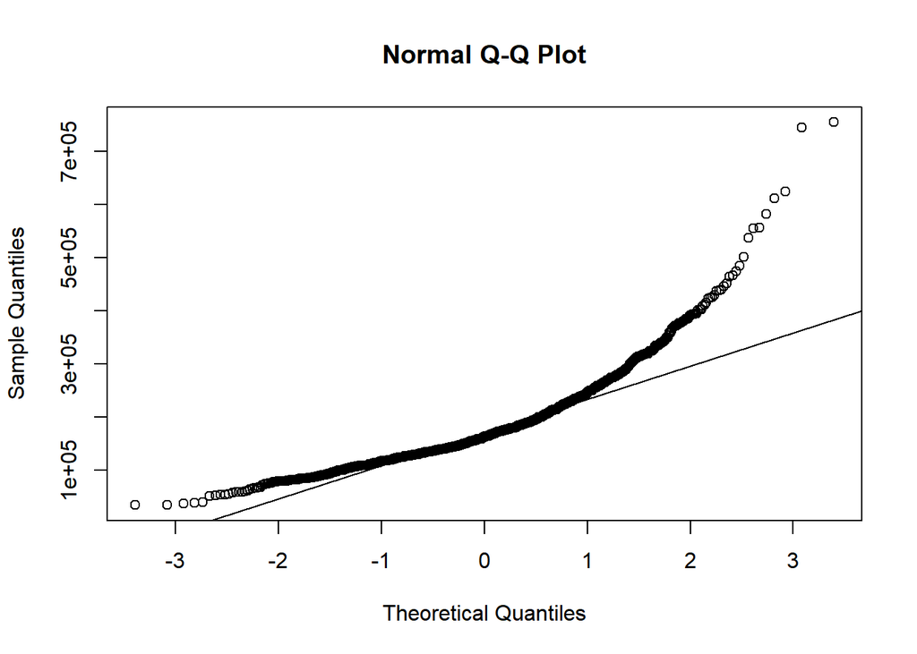

```r
qqnorm(all$SalePrice)
qqline(all$SalePrice)
```

1.87의 skew는 우편향으로 아주 높은 기울기이다. Q-Q plot의 판매가는 정규 분포가 아님을 보여준다. 판매가를 log 변환해서 조정하겠다.

```r
all$SalePrice <- log(all$SalePrice) # default is the natural logarithm
skew(all$SalePrice)
```

```
## [1] 0.1213182
```

보는 바와 같이, skew가 낮아졌고, Q-Q plot도 좋아졌다.

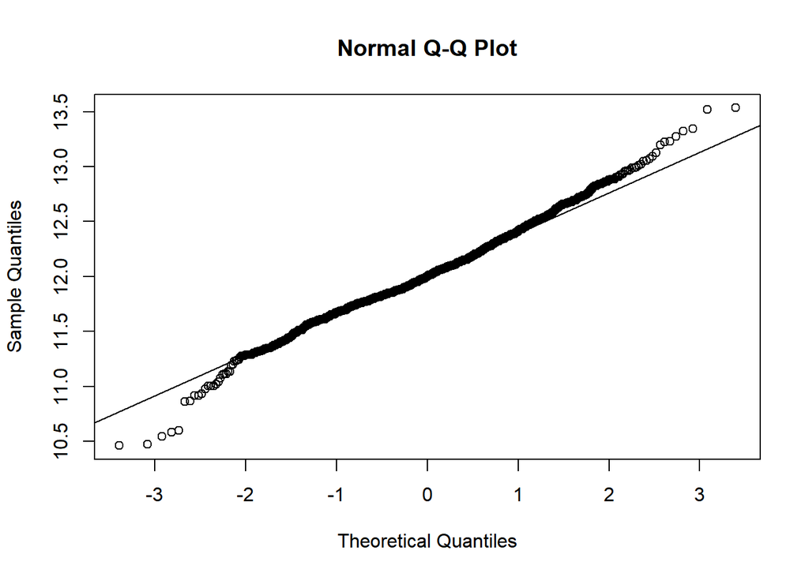

```r
qqnorm(all$SalePrice)
qqline(all$SalePrice)
```

## 7.5 Composing train and test sets

```r
train1 <- combined[!is.na(all$SalePrice),]
test1 <- combined[is.na(all$SalePrice),]
```

# 8 선형회귀분석

```r
head(train1,3)
```

```
##   LotFrontage    LotArea YearBuilt MasVnrArea BsmtFinSF2   BsmtUnfSF  X1stFlrSF
## 1 -0.04971228 -0.1017437 1.0470513  1.2245218 -0.3626439 -0.32481982 -0.7783464
## 2  0.57517451  0.1494097 0.1555794 -0.7926862 -0.3626439  0.01489152  0.4295679
## 3  0.08592286  0.4616028 0.9810163  1.1521856 -0.3626439  0.24103628 -0.5540170
##    X2ndFlrSF LowQualFinSF  GrLivArea BsmtFullBath BsmtHalfBath  FullBath
## 1  1.1978525    -0.116953  0.5701193    1.0900703   -0.2515929 0.7831023
## 2 -0.8627768    -0.116953 -0.3694659   -0.8185342    3.8867695 0.7831023
## 3  1.2021066    -0.116953  0.7046259    1.0900703   -0.2515929 0.7831023
##     HalfBath BedroomAbvGr KitchenAbvGr TotRmsAbvGrd Fireplaces GarageCars
## 1  1.2334526    0.1699579   -0.2005503    0.9921086 -0.9246045  0.3076852
## 2 -0.7554812    0.1699579   -0.2005503   -0.2864338  0.6263278  0.3076852
## 3  1.2334526    0.1699579   -0.2005503   -0.2864338  0.6263278  0.3076852
##   WoodDeckSF OpenPorchSF EnclosedPorch X3SsnPorch ScreenPorch    PoolArea
## 1 -0.9442794   0.8344301    -0.4276454  -0.112794  -0.3092074 -0.06407061
## 2  1.2548766  -1.0824844    -0.4276454  -0.112794  -0.3092074 -0.06407061
```

[output cut: 145 more lines]

# 9 Modeling

## 9.1 Lasso regression model

Ridge, Elastic Net model, Lasso 3가지 모델을 시도했는데 Lasso가 제일 나은 결과라서 Lasso만 적겠다. elastic-net 패널티는 알파와 Lasso(alpha = 1) & ridge(alpha = 0)간의 갭 사이에서 조정된다. 튜닝값 Lambda는 전반적인 패널티의 strength를 조정한다. Ridge 패널티는 독립 변수의 상관 계수를 줄이는 걸로 알려졌지만, Lasso는 하나는 택하고 다른건 버리는 걸로 알려졌다. 아래와 같이 caret 함수를 교차 검증하여 lambda에 쓸 best 값을 찾아냈고, 이건 lasso model에서 조정해야할 유일한 매개 변수다.

```r
set.seed(0224)
my_control <- trainControl(method = 'cv', number = 5)
lassoGrid <- expand.grid(alpha = 1, lambda = seq(0.001, 0.1, by = 0.0005))

lasso_mod <- train(x = train1, y = all$SalePrice[!is.na(all$SalePrice)], method ='glmnet', trControl= my_control, tuneGrid = lassoGrid)
lasso_mod$bestTune
```

```
##   alpha lambda
## 6     1 0.0035
```

```r
min(lasso_mod$results$RMSE)
```

```
## [1] 0.1144607
```

caret의 ‘varlmp’ 함수에는 다음과 같이 쓰여 있다. glmboost와 glmnet의 완벽한 상관 계수의 값을 위해 이에 대응하는 튜닝된 모델이 사용된다. 이것은 가장 중요한 변수의 실제 순위가 저장되지 않는다는 거지만, 이로 인해 모델에서 얼마나 많은 변수가 미사용 되는지를 알 수 있게 해준다.

```r
lassoVarImp <- varImp(lasso_mod, scale = F)
lassoImportance <- lassoVarImp$importance

varsSelected <- length(which(lassoImportance$Overall!=0))
varsNotSelected <- length(which(lassoImportance$Overall==0))

cat('Lasso uses', varsSelected, 'variables in its model, and did not select', varsNotSelected, 'variables.')
```

```
## Lasso uses 77 variables in its model, and did not select 105 variables.
```

```r
LassoPred <- predict(lasso_mod, test1)
predictions_lasso <- exp(LassoPred) #로그를 실수로 변환.
head(predictions_lasso)
```

```
##     1461     1462     1463     1464     1465     1466
## 113881.7 161035.1 178969.8 197308.6 205214.8 170425.7
```

## 9.2 XGBoost model

```r
xgb_grid = expand.grid(nrounds = 1000,
                       eta = c(0.1, 0.05, 0.01),
                       max_depth = c(2, 3, 4, 5, 6),
                       gamma = 0,
                       colsample_bytree = 1,
                       min_child_weight = c(1, 2, 3, 4, 5),
                       subsample = 1
                       )
```

```r
label_train <- all$SalePrice[!is.na(all$SalePrice)]

# Dmatrix로 testing & training data 분리
dtrain <- xgb.DMatrix(data = as.matrix(train1), label = label_train)
dtest <- xgb.DMatrix(data = as.matrix(test1))
```

```r
default_param <- list(
  objective = 'reg:linear',
  booster = 'gbtree',
  eat = 0.05, # default = 0.3,
  gamma = 0,
  max_depth = 3, # default = 6
  min_child_weight = 4, # default = 1,
  subsample = 1,
  colsample_bytree = 1
)
```

다음으로 최적의 라운드 수를 결정하기 위한 교차 검증(cross validation)을 하겠다(주어진 변수 셋에 대해)

```r
xgbcv <- xgb.cv( params = default_param, data = dtrain, nrounds = 500, nfold = 5, showsd = T, stratified = T, print_every_n = 40, early_stopping_rounds = 10, maximize = F)
```

[output not shown]

```r
# 교차 검증으로 찾은 최적의 iteration을 써서 모델 트레이닝
xgb_mod <- xgb.train(data = dtrain, parmas = default_param, nrounds = 454)
```

```
## [14:05:02] WARNING: amalgamation/../src/learner.cc:576:
## Parameters: { "parmas" } might not be used.
##
##   This could be a false alarm, with some parameters getting used by language bindings but
##   then being mistakenly passed down to XGBoost core, or some parameter actually being used
##   but getting flagged wrongly here. Please open an issue if you find any such cases.
```

```r
XGBpred <- predict(xgb_mod, dtest)
predictions_XGB <- exp(XGBpred) # 로그를 실수로 변환
head(predictions_XGB)
```

```
## [1] 123320.4 164879.0 204647.6 196793.4 204819.3 174563.3
```

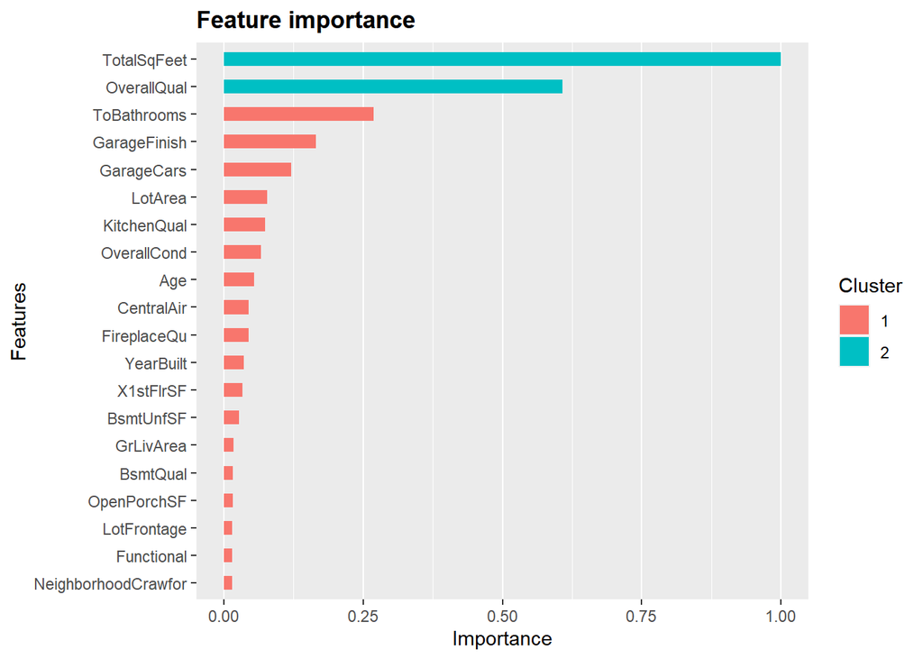

```r
# 변수 중요도 시각화
library(Ckmeans.1d.dp) # ggplot clustering을 위해 필요하다

mat <- xgb.importance(feature_names = colnames(train1), model = xgb_mod)
xgb.ggplot.importance(importance_matrix = mat[1:20], rel_to_first = TRUE)
```

## 9.3 예측 평균화

```r
sub_avg <- data.frame(ID = test_labels, SalePrice = (predictions_XGB + 2*predictions_lasso)/3)
head(sub_avg)
```

```
##        ID SalePrice
## 1461 1461  117027.9
## 1462 1462  162316.4
## 1463 1463  187529.1
## 1464 1464  197136.9
## 1465 1465  205083.0
## 1466 1466  171804.9
```